# Bayesian Genotyping

Dataset: big

31 October 2026

This is still a work in progress script, not yet final! All the necessary ASP function are loaded from asp_functions.R script

After completing this script, move on to 06_Visualisation_of_genototyping_resultsRmd

## 1 Libraries, settings, paths and basic setup

```r
suppressMessages({
  library(readxl)
  library(dplyr)
  library(readr)
  library(ggplot2)
  library(scales)
  library(parallel)
  library(rstan)
  library(knitr)
  library(bayesplot)
  library(patchwork)
})

# Settings come from the params block in the YAML header, this turns them into usable variables
invisible(list2env(params, envir = environment()))
settings_used <- data.frame(setting = c("run_date", names(params)),
                            value = c(format(Sys.time(), "%Y-%m-%d %H:%M"),
                                      vapply(params, function(setting_value) paste(setting_value, collapse = ", "), character(1))))
# Uploading shared functions
source("Code/R_scripts/asp_functions.R", local = TRUE)

plot_font <- "Times New Roman"
theme_set(theme_minimal(base_family = plot_font))
hm_dark <- "#476F84"
ht_dark <- "#A4552A"
correct_colour <- "#72874E" # correct calls, reads used
error_colour <- "#d73027" # miscalls, incorrect calls, removing cutoffs
group_colours <- c("All pairs" = "grey25", "True homozygotes" = hm_dark, "True heterozygotes" = ht_dark)


# Folder names are built with a shared function inside asp_functions.R, it gives a unique name based on changed settings for every run. If you use the same settings to rerun it again it gets overwritten.
run_names <- build_run_names(input_type, use_anchors, anchor_length, threshold_type, error_rate, min_score_fraction,
                             prior_type, prior_het_share, prior_population, prior_floor, probe_type = probe_type,
                             ancestry_prior_shape = ancestry_prior_shape, phi_hom_structure = phi_hom_structure)
output_folder_name_identified <- file.path("Results", dataset_name, "Genotypes_results", run_names$asp_run_name)
stopifnot("ASP results folder not found, run 04_SNP_Genotyping_ASP_primer.Rmd first with the same settings" = dir.exists(output_folder_name_identified))

# Graphics folders for stan and downsampling plots
stan_graphics_folder <- file.path("Results", dataset_name, "Graphics", "STAN_Hierarchical", run_names$bayes_settings_label)
read_depths_to_test <- unlist(read_depths_to_test)
downsampling_output_folder <- file.path(stan_graphics_folder,
                                        paste0("Downsampling_calibration", if (strand_downgrade) "_sdown" else "_sflag",
                                               sprintf("_r%d_d%d_n%d", minimum_reads_for_truth_pair, max(read_depths_to_test), draws_per_depth)))

# primer panel, only locus and the two alleles are needed here (copied from 04, without trimming and anchors)
# the sheet is read once: panel_sheet keeps every column (also the allele frequencies for the HWE prior), panel only the columns needed here
panel_sheet <- read_excel(primer_panel_path, sheet = "Final panel", .name_repair = "minimal")
panel <- panel_sheet[, c("SNP name", "Allele 1", "Allele 2", "ASP1_SEQ (forward allele1)", "ASP2_SEQ (forward allele2)")]
names(panel) <- c("locus", "allele1", "allele2", "asp1_seq", "asp2_seq")
panel <- panel[!is.na(panel$asp1_seq) & !is.na(panel$asp2_seq), ]


timing_log <- list() # empty timing log, log_time() adds one row per step
```

## 2 Hierarchical model for missclasification rate

This chunk contains hierarchical base mixture Bayesian genotyper model for identified Obitools reads, it does one stan call for all samples and loci together. It takes the allele counts for every sample locus pair where k = allele1 reads and d = all usable reads, it doesn’t run on reads itself just the genotype deciding process. The naive caller uses a fixed rule for every sample locus pair, if MAF reaches over 20 % the pair is called HT otherwise its HM. Where it lacks is that it treats every locus and sample the same way (I get a results, a specific genotype, but I’m not sure how confident that result is, depth 10 and depth 300 genotypes look the same on the end results heatmap). This Stan model is a bit more sophisticated because it goes around this a different way, it asks “given how noisy this one locus sample pair is, how likely are these allele counts under each genotype?”. Why use hierarchical? If i want to estimate error rate at each locus i have different ways of computing it on 24 sample and 33 loci. Either with full complete pooling of and treat all loci the same, throw all reads together and compute one global error rate. Its simple, but it lacks nuance. One loci might have a higher error rate because of the homopolymer site right before the SNP position (5 %) and a clean locus could have 0.3 % error rate. One shared value can be too strict or too loose for different loci. Second option is without pooling and treat every locus separately on its own reads. This option is completely valid, it removes the previous problem but a new one appears. Not all loci have the same amount of depth and data to work with and when there is not a lot of data to work with each estimate relies too much on pure chance. Third option is partial or hierarchical pooling. It treats each loci separately, but still takes in count that they “come from the same background”. Loci are related but not exactly identical (same chemistry, sequencer, pipeline). Each locus gets its own error rate, but those rate are assumed to come from one shared distribution (errors rate is about 3 % but they scatter around by some estimated amount). The model learns both those values, typical error rate and how much loci really differ (mu_error and sigma_error_locus). Each locus gets its own value but it comes from its own data and the families typical value and that ratio of reliance is based on amount of evidence (depth, number of reads) for each locus separately. Lower depth locus relies more on (is pulled more towards) the typical “family” values, and a locus with more informative reads and higher depth is relies more on its own data. The same can happen for samples, one can have a higher error rate because DNA is more degraded. A sample with few reads can borrow from strength from other. Error rate is calculated as pair error rate = typical value + locus effect + sample effect (mu_error + sigma_error_locus * z_error_locus + sigma_error_sample * z_error_sample). Heterozygote allele balance is pooled the same way. its better for genotyping low depth pairs, they can produce overconfident (0 % or 10 %) and extreme estimates and partial pooling pulls it more towards the shared value which makes GQ more meaningful.

Overdispersion: Model handles it in two ways: which DNA molecules happened to be copied and which happened to be sequenced. A simple binomial model would treat reads for a HT (CT) like coin flips. If every read were an independent “coin flip” from DNA, each read would get a fair chance to be 50 % c or T. The more depth and reads you have, lower the dispersion and closer it is to a true 50 50 split. But reads arent really independent, they come from template molecules, which read get mulitiplied in the PCR is random which affects sequences and reads background. Sequencing more reads or having more depth and data doesnt necessarily give a closer true independent state it just gives a better estimate for that specific split that happened during the labratory prep. Beta binomial models this with two steps, a true share of copied DNA for specific paris varies at around 50 % (step 1) and the reads are coin flips from that share (step 2). How much step 1 varies is set by phi which can be treated as number of effective templates or molecules. Lower amount of them means more scatter, more of them means it behaves more like plain binomial. This model fits two of them phi_het for HT with a prior of around 30 molecules and phi_hom and for minor allele reads in HM with a prior at around 200. With binomials more reads give less scatter, but with betabinomial more reads doesnt neccesarily mean the same thing, scatter levels at around +-9 % because the limit are the molecules not the reads. Example: HT with 200 reads (140:60 - 30 % for minor) with binomial that is far away from 5050 split (chance of 0.000002%), model would push it towards HM even though that amount of MAF is not typical for HM. With betabinomial that chance is at around 4 %, rare but not almost impossible. Same example but with 20 reads (14:6), binomial gives it 11.5 % and betabinomial 22 %. Phi_het also has limits set to at least 10. And its the same for all counts for every sample and locus that is not exactly accurate with reality where low DNA sample has fewer molecules than higher quality DNA sample. Downsampling shows HT are overconfident, for which this one shared phi might be the culprit. Pairs with fewer molecules scatter more than phi allows and the model is too sure about them. That is why an updated model now uses phi_het separated between samples with the same partial pooling.

Allele bias per locus: in theory two allele specific priors per locus should have the same shares and are present in equal amounts in HT. In practice those two arent identical, one may bind a little better at the end, that primers specific bindings probabilities can be the cause of the MAF and different split between alleles. This model learns the expected HT split for every locus (het_fraction), its partially pooled across loci like the error rate (a locus with only two HT can claim a strong bias with that little amount of information) and it also has safety limits het_min and 1 - het_min (0.2 to 0.8). This can change confident HM calls into less confident HM calls or even HT. A lot of information comes from GQ which gives you confidence on the same scale as Phred

```r
# Folder name preparation based on previous ASP run and settings used
settings_suffix_hier <- basename(run_names$asp_run_name) # same settings label
prior_label_hier <- run_names$prior_label
output_folder_name_hier <- file.path("Results", dataset_name, "Genotypes_results", run_names$bayes_run_name)
dir.create(output_folder_name_hier, showWarnings = FALSE, recursive = TRUE)

# Settings used each run saved directly inside the output folder, useful for reproducibility
write.table(settings_used, file.path(output_folder_name_hier, "settings_used.tsv"), sep = "\t", row.names = FALSE, quote = FALSE)

# PAth to the stan model, compiled model is saved next to it
stan_model_path_hier <- "Stan_config/base_mixture_model_hierarchical.stan"
rstan_options(auto_write = TRUE)
mixture_stan_hier_model <- stan_model(stan_model_path_hier)

# Reads from the folder not R memory, reads the result files from ASP genotyper pipeline
reads_hier <- read_tsv(file.path(output_folder_name_identified, "all_barcodes_asp_reads.tsv"), show_col_types = FALSE,
                       col_types = cols(called_allele = col_character(), called_allele_raw = col_character(), .default = col_guess()))
naive_genotypes_hier <- read_tsv(file.path(output_folder_name_identified, "all_barcodes_asp_genotypes.tsv"), show_col_types = FALSE,
                                 col_types = cols(genotype = col_character(), strand_check = col_character(), .default = col_guess()))
cat(sprintf("Stan input: %s (%d reads)\n", run_names$asp_run_name, nrow(reads_hier)))

# Allele counts from the scorer function, only reads that passed every filter
counts_hier <- reads_hier %>%
  filter(!is.na(called_allele)) %>%
  left_join(panel[, c("locus", "allele1", "allele2")], by = "locus") %>%
  group_by(barcode, locus) %>%
  summarise(k = sum(called_allele == allele1),
            d = sum(called_allele == allele1 | called_allele == allele2),
            .groups = "drop") %>%
  filter(d >= minimum_required_depth)

# Check that the reads and depth are the same
depth_check_hier <- inner_join(counts_hier, naive_genotypes_hier[, c("barcode", "locus", "depth")], by = c("barcode", "locus"))
stopifnot("reads and genotypes file are from different ASP runs (Stan depth != ASP depth)" = all(depth_check_hier$d == depth_check_hier$depth),
          "the fitted pairs are not the ASP-called pairs" = nrow(counts_hier) == sum(naive_genotypes_hier$status == "called"))

samples_hier <- sort(unique(counts_hier$barcode))
loci_hier <- sort(unique(counts_hier$locus))

# Genotype prior for every locus taken from primer panel when setting is set to "HWE", column taken based on population set
if (prior_type %in% c("hwe", "ancestry")) {
  allele1_frequency_hier <- data.frame(
    locus = panel_sheet[["SNP name"]],
    frequency = as.numeric(panel_sheet[[match(prior_population, names(panel_sheet))]]), # match() takes the first column with this name = allele 1
    dog_frequency = as.numeric(panel_sheet[[match("FreqDOG", names(panel_sheet))]])) # dog side, only used by "ancestry"
}

# This builds the genotype prior for every pair one row per pairs. Prior is chosen from the settings
pair_prior_hier <- switch(prior_type,
  flat = matrix(1/3, nrow = nrow(counts_hier), ncol = 3),
  het_share = matrix(rep(c((1 - prior_het_share) / 2, (1 - prior_het_share) / 2, prior_het_share), each = nrow(counts_hier)), ncol = 3),
  hwe = {
    allele1_p <- allele1_frequency_hier$frequency[match(counts_hier$locus, allele1_frequency_hier$locus)]
    allele1_p <- pmin(pmax(ifelse(is.na(allele1_p), 0.5, allele1_p), prior_floor), 1 - prior_floor) # missing frequency = 0.5, then floored
    cbind(allele1_p^2, (1 - allele1_p)^2, 2 * allele1_p * (1 - allele1_p)) # Hardy-Weinberg: p^2, q^2, 2pq
  },
  ancestry = matrix(1/3, nrow = nrow(counts_hier), ncol = 3)) # placeholder, Stan builds the ancestry prior itself (replaced by the fitted prior after sampling)
colnames(pair_prior_hier) <- c("prior_hom1", "prior_hom2", "prior_het")

# This list is taken by STAN, this is the data that goes into stan model. Everything is turned into number for stan, because it cant use names fro samples or loci
stan_data_hier <- list(
  N = nrow(counts_hier), # number of pairs
  S = length(samples_hier), # number of samples
  L = length(loci_hier), # number of loci
  sample_id = as.integer(factor(counts_hier$barcode, levels = samples_hier)), # Position (indices) of each which sample and locus belongs specific pair
  locus_id = as.integer(factor(counts_hier$locus, levels = loci_hier)),
  k = as.integer(counts_hier$k), # reads for allele 1
  d = as.integer(counts_hier$d), # all filtered reads
  max_error = max_error, # cap on any error rate
  het_min = HT_min_frequence, # heterozygote allele1 fraction stays between 0.2 and 0.8 (1 - HT_minor_frequence)
  pair_prior = unname(pair_prior_hier), # genotype prior for every pair, same order as counts_hier (rows add up to 1), names are removed
  use_ancestry = as.integer(prior_type == "ancestry"), # 1 = Stan learns a wolf ancestry per sample and builds the prior from it
  p_wolf = if (prior_type == "ancestry") pmin(pmax(coalesce(allele1_frequency_hier$frequency[match(loci_hier, allele1_frequency_hier$locus)], 0.5), prior_floor), 1 - prior_floor) else rep(0.5, length(loci_hier)), # per locus in loci_hier order, missing = 0.5, floored
  p_dog = if (prior_type == "ancestry") pmin(pmax(coalesce(allele1_frequency_hier$dog_frequency[match(loci_hier, allele1_frequency_hier$locus)], 0.5), prior_floor), 1 - prior_floor) else rep(0.5, length(loci_hier)),
  ancestry_prior_shape = ancestry_prior_shape,
  phi_hom_by_locus = as.integer(phi_hom_structure %in% c("locus", "locus_sample")), # homozygote overdispersion per locus (partially pooled)
  phi_hom_by_sample = as.integer(phi_hom_structure %in% c("sample", "locus_sample")) # homozygote overdispersion per sample (partially pooled)
)

cat(sprintf("Gathered %d pairs (%d samples x %d loci) - running ONE hierarchical Stan call | genotype prior: %s\n",
            stan_data_hier$N, stan_data_hier$S, stan_data_hier$L, prior_label_hier))
```

```r
t0 <- Sys.time()

### Actual run for the Bayesian model, finds which parameters fit my data with MCMC sampling and saves all the combinations. results are average of these draws. It runs 4 independent chains with discarded warmup.
fit_hier <- sampling(
  mixture_stan_hier_model, # compiled model from stan file
  data = stan_data_hier,
  iter = stan_iter, warmup = stan_warmup, chains = stan_chains, cores = min(stan_chains, n_cores),
  control = list(adapt_delta = stan_adapt_delta), # smaller steps, avoids divergences in hierarchical models
  refresh = 0, seed = 1, # no progress messages, same seed for same results when reruning
  pars = "log_genotype_prior", include = FALSE # the per-pair prior is rebuilt in R from wolf_ancestry, not stored for every draw
)
log_time(sprintf("hierarchical sampling: %d pairs", stan_data_hier$N), t0)

# Chain convergence check. Rhat checks if the chains agree (should be at around 1.00, if they disagree > 1.00)- Rhat compares two different spreads within each chain (variations of values inside the chain) and between chains (how far apart the averages are). Rhat should be below 1.01
hyper_pars_hier <- c("mu_error", "sigma_error_locus", "sigma_error_sample", "mu_bias", "sigma_bias", "phi_het", "sigma_phi_het", "phi_hom_typical",
                     if (stan_data_hier$phi_hom_by_locus == 1) "sigma_phi_hom_locus",
                     if (stan_data_hier$phi_hom_by_sample == 1) "sigma_phi_hom_sample") # spreads only when they are estimated
hyper_summary_hier <- summary(fit_hier, pars = hyper_pars_hier)$summary
hyper_labels_hier <- c(mu_error = "Typical error rate (logit scale)",
                       sigma_error_locus = "Error rate spread between loci",
                       sigma_error_sample = "Error rate spread between samples",
                       mu_bias = "Typical heterozygote allele bias (logit scale)",
                       sigma_bias = "Allele bias spread between loci",
                       phi_het = "Effective molecules in heterozygotes (typical sample)",
                       sigma_phi_het = "Effective molecules spread between samples (log scale)",
                       phi_hom_typical = "Homozygote overdispersion (typical pair)",
                       sigma_phi_hom_locus = "Homozygote overdispersion spread between loci (log scale)",
                       sigma_phi_hom_sample = "Homozygote overdispersion spread between samples (log scale)")
kable(data.frame(parameter = hyper_labels_hier[rownames(hyper_summary_hier)],
                 hyper_summary_hier[, c("mean", "2.5%", "97.5%", "n_eff", "Rhat")], check.names = FALSE), digits = 3, row.names = FALSE)

# Grabs the worst Rhat
max_rhat_hier <- max(summary(fit_hier)$summary[, "Rhat"], na.rm = TRUE)
cat(sprintf("Max Rhat: %.3f | divergent transitions: %d | max treedepth hits: %d\n", max_rhat_hier,
            get_num_divergent(fit_hier), get_num_max_treedepth(fit_hier)))

# Extracts all the info about the draws
draws_hier <- extract(fit_hier, c("posterior", "error_locus", "error_sample", "het_fraction", "phi_het", "phi_het_sample", "phi_hom_typical", "phi_hom_pair"))

# Per pair means of all the draws
post_hier <- apply(draws_hier$posterior, c(2, 3), mean)

# Ancestry prior: the prior of every pair is learned, so the prior columns and the downsampling use its posterior mean (averaged over the draws)
if (prior_type == "ancestry") {
  wolf_ancestry_draws <- extract(fit_hier, "wolf_ancestry")$wolf_ancestry # draws x samples
  allele1_p_draws <- wolf_ancestry_draws[, stan_data_hier$sample_id] * rep(stan_data_hier$p_wolf[stan_data_hier$locus_id] - stan_data_hier$p_dog[stan_data_hier$locus_id], each = nrow(wolf_ancestry_draws)) +
    rep(stan_data_hier$p_dog[stan_data_hier$locus_id], each = nrow(wolf_ancestry_draws)) # q * p_wolf + (1 - q) * p_dog, draws x pairs
  pair_prior_hier <- cbind(prior_hom1 = colMeans(allele1_p_draws^2), prior_hom2 = colMeans((1 - allele1_p_draws)^2), prior_het = colMeans(2 * allele1_p_draws * (1 - allele1_p_draws)))
}

# Parameters for each locus, error rate for average sample and HT allele 1 fraction
locus_params_hier <- data.frame(
  locus = loci_hier,
  error_rate_locus = round(colMeans(draws_hier$error_locus), 5),
  het_fraction = round(colMeans(draws_hier$het_fraction), 4))

# Parameters for every sample, error rate and and phi_het_sample which are effective starting molecules of the samples HT (for overdispersion)
sample_params_hier <- data.frame(
  barcode = samples_hier,
  error_rate_sample = round(colMeans(draws_hier$error_sample), 5),
  phi_het_sample = round(colMeans(draws_hier$phi_het_sample), 1))

if (prior_type == "ancestry") {
  sample_params_hier$wolf_ancestry <- round(colMeans(wolf_ancestry_draws), 3) # 0 = dog, 1 = wolf
  sample_params_hier$wolf_ancestry_low <- round(apply(wolf_ancestry_draws, 2, quantile, 0.025), 3) # 95 % credible interval
  sample_params_hier$wolf_ancestry_high <- round(apply(wolf_ancestry_draws, 2, quantile, 0.975), 3)
}

# This the Rstan results table, one row per fitted pair with info about priors used, posterior porbability for all three genotypes per pair, maximum posterior (genotype) and actual genotype (aa, ct, cc, ...), margin, GQ.
stan_rows_hier <- counts_hier %>%
  left_join(panel[, c("locus", "allele1", "allele2")], by = "locus") %>%
  mutate(
    prior_het = round(pair_prior_hier[, "prior_het"], 4),
    posterior_hom1 = round(post_hier[, 1], 4),
    posterior_hom2 = round(post_hier[, 2], 4),
    posterior_het = round(post_hier[, 3], 4),
    genotype_key = max.col(post_hier, ties.method = "first"),
    genotype_stan = ifelse(genotype_key == 1, paste0(allele1, allele1),
                    ifelse(genotype_key == 2, paste0(allele2, allele2),
                           paste0(pmin(allele1, allele2), pmax(allele1, allele2)))), # Alphabeticaly sorted
    max_posterior = round(apply(post_hier, 1, max), 4),
    margin = round(apply(post_hier, 1, function(p) diff(sort(p, decreasing = TRUE)[2:1])), 4),
    GQ = round(pmin(99, -10 * log10(pmax(1 - apply(post_hier, 1, max), 1e-10))), 1)
  ) %>%
  select(barcode, locus, k, genotype_stan, prior_het, posterior_hom1, posterior_hom2, posterior_het, max_posterior, margin, GQ)
```

```r
# Combined table for both runs, the naive one and Bayes, with strand check and QD, depth aswell.
combined_genotypes_hier <- naive_genotypes_hier %>%
  select(barcode, locus, genotype_naive = genotype, depth, status, strand_check, QD) %>%
  left_join(stan_rows_hier, by = c("barcode", "locus")) %>%
  left_join(locus_params_hier, by = "locus") %>%
  left_join(sample_params_hier, by = "barcode") %>%
  mutate(
    genotype = ifelse(genotype_stan != genotype_naive & strand_check %in% "failed" & # final genotype change when strand check si true
                        substr(genotype_stan, 1, 1) != substr(genotype_stan, 2, 2),
                      genotype_naive, genotype_stan),
    changed = !is.na(genotype_naive) & !is.na(genotype) & genotype_naive != genotype
  ) %>%
  select(barcode, locus, genotype, genotype_stan, genotype_naive, depth, k, status, strand_check, QD,
                prior_het, posterior_hom1, posterior_hom2, posterior_het, max_posterior, margin, GQ,
                error_rate_locus, error_rate_sample, phi_het_sample, het_fraction, changed)

# Final results table writing per sample
for (id in unique(combined_genotypes_hier$barcode)) {
  write_tsv(combined_genotypes_hier %>% filter(barcode == id),
            file.path(output_folder_name_hier, paste0(id, "_base_mixture_genotypes_hierarchical.tsv")))
}

# Data for loci, samples and combined table saved separately
write_tsv(combined_genotypes_hier, file.path(output_folder_name_hier, "all_barcodes_base_mixture_genotypes_hierarchical.tsv"))
write_tsv(locus_params_hier, file.path(output_folder_name_hier, "locus_parameters_hierarchical.tsv"))
write_tsv(sample_params_hier, file.path(output_folder_name_hier, "sample_parameters_hierarchical.tsv"))

#Posterior draws and other objects for the plots in .rds format
saveRDS(list(fit_hier = fit_hier, draws_hier = draws_hier, stan_data_hier = stan_data_hier, stan_rows_hier = stan_rows_hier,
             samples_hier = samples_hier, loci_hier = loci_hier, post_hier = post_hier,
             combined_genotypes_hier = combined_genotypes_hier),
        file.path(output_folder_name_hier, "stan_plot_inputs.rds"))
# Convergence table, all the parameters summary
write_tsv(data.frame(parameter = rownames(hyper_summary_hier), hyper_summary_hier, check.names = FALSE),
          file.path(output_folder_name_hier, "hyperparameters_hierarchical.tsv"))

# Overall summary for html presentation
summary_hier <- data.frame(
  summary = c("Results folder", "ASP settings", "Genotype prior",
              "All pairs (samples x loci)", "Called", "Low depth", "No coverage",
              "Stan genotype differs from naive", "Stan HT replaced by the strand check",
              "Calls with max posterior < 0.99",
              "phi_het, typical sample (effective molecules in a heterozygote)", "phi_het, range across samples", "phi_hom, typical pair", "phi_hom, range across pairs"),
  value = c(gsub("([_/])", "\\1\u200b", output_folder_name_hier), settings_suffix_hier, gsub("_", "_\u200b", prior_label_hier),
            nrow(combined_genotypes_hier),
            sum(combined_genotypes_hier$status == "called"),
            sum(combined_genotypes_hier$status == "low_depth"),
            sum(combined_genotypes_hier$status == "no_coverage"),
            sum(combined_genotypes_hier$changed, na.rm = TRUE),
            sum(combined_genotypes_hier$genotype_stan != combined_genotypes_hier$genotype, na.rm = TRUE),
            sum(combined_genotypes_hier$max_posterior < 0.99, na.rm = TRUE),
            sprintf("%.1f", mean(draws_hier$phi_het)),
            sprintf("%.1f-%.1f", min(sample_params_hier$phi_het_sample), max(sample_params_hier$phi_het_sample)),
            sprintf("%.1f", mean(draws_hier$phi_hom_typical)),
            sprintf("%.0f-%.0f", min(colMeans(draws_hier$phi_hom_pair)), max(colMeans(draws_hier$phi_hom_pair)))))

kable(summary_hier, col.names = c("", ""))
kable(combined_genotypes_hier %>% filter(changed) %>%
        select(barcode, locus, genotype_naive, genotype, depth, k, prior_het, posterior_het, error_rate_locus))

if (prior_type == "ancestry") kable(sample_params_hier[, c("barcode", "wolf_ancestry", "wolf_ancestry_low", "wolf_ancestry_high")],
                                    col.names = c("Sample", "Wolf ancestry", "2.5 %", "97.5 %"))
```

## 3 Downsampling and genotype confidence calibration

Calibration statistics are calculated for the stan calls: Brier score, Brier skill score, ECE, Spiegelhalter Z (for all, and HM HT separately). Calibration is needed to check how over or under confident the model is or HT and HM calls, it checks if calls with 1 % error rate are actually wrong 1 % of the time. For example: If HM calls have 2.7 % error rate and were wrong 0.8 % they are too cautious, and if my HT calls have error rate of about 5.4 % and were wrong 10 % of the time they are too confident. Brier score is the average of squared (claimed probability - 0 or 1), where minus 1 when right and -0 when wrong. Lower score is better. Because the naive caller is always 100 % sure its Brier score is just the error rate. Brier skill score, compares Brier score with a simple forecaster which give every call the same overall accuracy. If its above 0 it means Stans individual probabilities add information, below 0 means they are worse than just one flat number. ECE is the expected calibration error, its the average gaps between the observed and claimed error across all GQ bins, weighted by the number of calls in the bin (0 is perfect). Spiegelhalter Z is a significance tedt of calibration, at around 0 it means it’s calibrated, above +2 over confident, below -2 too cautious,

Bootstraping, it gives uncertantiy bands for results. Treatinf every downsampled call as independent is incorrect because all the subsampled read cluster come from the same locus sample pair. If the original pair for lets say HT inherits some unnusal split of 35:65, all the subsamples will as well. There are really 749 independent pairs. treating every call as indepdent would make the boostrapped bands too narrow. It draws with replacememnt from 749 pairs HM and HT separately, recomputes error rates and statisctis.

Plot for GQ threshold trade off, if i use it as a filter, how many call are kept and how many of the errors can i get rid of.

```r
# Check if the first chunk ran
stopifnot("run the Stan chunk first" = exists("combined_genotypes_hier"))
dir.create(downsampling_output_folder, showWarnings = FALSE, recursive = TRUE)

# Reference genotypes and settings
reference_genotypes_file <- file.path("Data/Supporting_data/Reference_genotypes", paste0("genotypes_", dataset_name, ".tsv"))
read_depths_to_test <- unlist(read_depths_to_test) # the YAML list becomes a plain number vector
gq_bin_edges <- c(seq(0, 30, by = 2.5), 35, 40, 50, Inf)
gq_thresholds_to_test <- 1:40 # GQ thresholds for the trade-off plot
stopifnot("the deepest read depth to test must not be larger than minimum_reads_for_truth_pair" = max(read_depths_to_test) <= minimum_reads_for_truth_pair)

### Helper functions
# Makes sure the alleles are always in the same alpabetical order (reference panel was not created inside the script, so it might have different labels)
sort_alleles_in_genotype <- function(genotype) ifelse(is.na(genotype), NA_character_,
                                                      paste0(pmin(substr(genotype, 1, 1), substr(genotype, 2, 2)),
                                                             pmax(substr(genotype, 1, 1), substr(genotype, 2, 2))))

# Stans genotype function, it computes three genotype probabilities the same way as .stan file does with k allele 1 reads out of d possible reads. It uses the values the fitted model learned from for that specific locus sample pair. This is the part of the analysis which enables downsampling without running stan again which would take a lot longer.
stan_genotype_posterior <- function(k, d, error_rate, het_fraction, phi_het, phi_hom, genotype_prior) {
  log_beta_binomial <- function(k, d, a, b) lchoose(d, k) + lbeta(k + a, d - k + b) - lbeta(a, b)
  het_allele1_share <- het_fraction * (1 - error_rate) + (1 - het_fraction) * error_rate # read errors inside HT
  log_likelihoods <- cbind(log_beta_binomial(k, d, (1 - error_rate) * phi_hom, error_rate * phi_hom), # HM1
                           log_beta_binomial(k, d, error_rate * phi_hom, (1 - error_rate) * phi_hom), # HM2
                           log_beta_binomial(k, d, het_allele1_share * phi_het, (1 - het_allele1_share) * phi_het)) #HT
  log_prior_times_likelihood <- log(genotype_prior) + log_likelihoods # prior * likelihood in log (+)
  scaled_values <- exp(log_prior_times_likelihood - apply(log_prior_times_likelihood, 1, max)) # subtract the max first, to avoid really small values (end results is the same because the exp(A - n) = exp(A) * exp-(n), the exp(-n) cancels in the division)
  scaled_values / rowSums(scaled_values) # divided by their sum = posterior (with a flat prior this is the normalised likelihood)
}
### Step 1: fitted model values and the reference set

# Table of every learned parameter for each pair for the downsampling, error rates, overdispersion values, prior, ....
fitted_pair_error_rates <- data.frame(
  barcode = counts_hier$barcode,
  locus = counts_hier$locus,
  error_rate_pair = colMeans(extract(fit_hier, "error_rate")$error_rate), # posterior mean per pair
  phi_het_pair = colMeans(draws_hier$phi_het_sample)[match(counts_hier$barcode, samples_hier)],
  phi_hom_pair = colMeans(draws_hier$phi_hom_pair), # homozygote overdispersion of every pair (shared, per locus and/or per sample)
  prior_hom1 = pair_prior_hier[, "prior_hom1"],
  prior_hom2 = pair_prior_hier[, "prior_hom2"],
  prior_het = pair_prior_hier[, "prior_het"])

# Ancestry prior in downsampling without reusing evidence. Each pairs prior comes from wolf ancestry of its sample estimated from the other loci only. A downsampled pairs is never scored based on a prior built with the full depth of reads, so the evidence of the locus is not reused when doing the downsampling. Ancestry posterior is evaluated on a grid from the called genotypes and fixed wolf or dog allele frequencies  (hybrid-index likelihood, Buerkle 2005).
if (prior_type == "ancestry") {
  ancestry_grid <- seq(0.0005, 0.9995, by = 0.001) # every wolf ancestry value that is tried
  pair_genotype_class <- max.col(post_hier, ties.method = "first") # full-depth call of every pair: 1 = hom1, 2 = hom2, 3 = het
  grid_allele1_p <- outer(ancestry_grid, stan_data_hier$p_wolf[stan_data_hier$locus_id]) +
    outer(1 - ancestry_grid, stan_data_hier$p_dog[stan_data_hier$locus_id]) # allele1 frequency for every ancestry value (rows) and pair (columns)
  called_class <- matrix(pair_genotype_class, nrow = length(ancestry_grid), ncol = length(pair_genotype_class), byrow = TRUE)
  log_called_genotype <- log(ifelse(called_class == 1, grid_allele1_p^2,
                                    ifelse(called_class == 2, (1 - grid_allele1_p)^2, 2 * grid_allele1_p * (1 - grid_allele1_p)))) # how likely each pair's call is under each ancestry value
  log_sample_total <- t(rowsum(t(log_called_genotype), stan_data_hier$sample_id)) # summed over all loci of each sample
  log_without_own_locus <- log_sample_total[, stan_data_hier$sample_id] - log_called_genotype +
    dbeta(ancestry_grid, ancestry_prior_shape, ancestry_prior_shape, log = TRUE) # the pair's own locus taken out, Beta prior added
  ancestry_weights <- exp(sweep(log_without_own_locus, 2, apply(log_without_own_locus, 2, max))) # max subtracted first to avoid tiny numbers
  ancestry_weights <- sweep(ancestry_weights, 2, colSums(ancestry_weights), "/") # weights of every pair sum to 1
  fitted_pair_error_rates$prior_hom1 <- colSums(ancestry_weights * grid_allele1_p^2)
  fitted_pair_error_rates$prior_hom2 <- colSums(ancestry_weights * (1 - grid_allele1_p)^2)
  fitted_pair_error_rates$prior_het <- colSums(ancestry_weights * 2 * grid_allele1_p * (1 - grid_allele1_p))
}

# Importing reference genotypes
reference_genotypes <- read_tsv(reference_genotypes_file, show_col_types = FALSE) %>%
  select(barcode = sample_id, locus, reference = genotype)

# Truth pairs which match every criteria for the downsampling, they have a reference, are correct and have enough reads
truth_pairs <- combined_genotypes_hier %>%
  filter(status == "called", depth >= minimum_reads_for_truth_pair) %>%
  inner_join(reference_genotypes, by = c("barcode", "locus")) %>%
  filter(!is.na(reference)) %>%
  mutate(reference_sorted = sort_alleles_in_genotype(reference)) %>%
  filter(reference_sorted == sort_alleles_in_genotype(genotype_naive)) %>%
  select(barcode, locus, reference_sorted) %>%
  left_join(panel[, c("locus", "allele1", "allele2")], by = "locus") %>%
  left_join(fitted_pair_error_rates, by = c("barcode", "locus")) %>%
  left_join(locus_params_hier[, c("locus", "het_fraction")], by = "locus") %>%
  mutate(pair_id = paste(barcode, locus, sep = "|"),
         true_class = ifelse(substr(reference_sorted, 1, 1) == substr(reference_sorted, 2, 2), "True homozygotes", "True heterozygotes"))
```

```r
cat(sprintf("Truth set: %d pairs (%d homozygous, %d heterozygous) with >= %d reads and a full-depth call matching the reference | Stan prior: %s\n",
            nrow(truth_pairs), sum(truth_pairs$true_class == "True homozygotes"),
            sum(truth_pairs$true_class == "True heterozygotes"), minimum_reads_for_truth_pair, prior_label_hier))

# All the usable reads from the pipeline and returns small table for every pair
reads_by_truth_pair <- reads_hier %>%
  filter(!is.na(called_allele)) %>%
  mutate(pair_id = paste(barcode, locus, sep = "|")) %>%
  filter(pair_id %in% truth_pairs$pair_id) %>%
  select(pair_id, called_allele, direction) %>%
  split(~ pair_id)

### Step 2: Draw reads and naive calls

# Downsampling function
downsample_and_call_one_pair <- function(pair_id) {
  pair_reads <- reads_by_truth_pair[[pair_id]]
  allele1_of_pair <- truth_pairs$allele1[match(pair_id, truth_pairs$pair_id)]
  depth_of_each_draw <- rep(read_depths_to_test, each = draws_per_depth) # draws needed
  allele1_reads_in_draw <- integer(length(depth_of_each_draw)) # k
  naive_genotype <- character(length(depth_of_each_draw)) # naive call, with the pipeline's strand setting
  for (i in seq_along(depth_of_each_draw)) {
    kept_reads <- sample.int(nrow(pair_reads), depth_of_each_draw[i]) # picks random reads without replacement
    kept_alleles <- pair_reads$called_allele[kept_reads]
    allele1_reads_in_draw[i] <- sum(kept_alleles == allele1_of_pair)
    naive_genotype[i] <- unname(call_genotype(kept_alleles, pair_reads$direction[kept_reads],
                                              minimum_required_depth = minimum_required_depth, HT_min_frequence = HT_min_frequence,
                                              strand_flag_prob = strand_flag_prob, expected_minor_fraction = expected_minor_fraction,
                                              strand_downgrade = strand_downgrade)["genotype"])
  }
  data.frame(pair_id = pair_id, depth = depth_of_each_draw, k = allele1_reads_in_draw, genotype_naive = naive_genotype)
}

# Random number generator which works in parallel
default_random_generator <- RNGkind()[1]
RNGkind("L'Ecuyer-CMRG") # switch to reproducible random numbers across mclapply workers, with no overlap
set.seed(1) # same for every run
t0 <- Sys.time()

# Running the downsampling
downsampled_list <- mclapply(truth_pairs$pair_id, downsample_and_call_one_pair, mc.cores = n_cores)
RNGkind(default_random_generator) # back to the session's default generator
failed_pairs <- vapply(downsampled_list, function(result) is.null(result) || inherits(result, "try-error"), logical(1)) # mclapply returns errors (or NULL for a killed worker) instead of stopping # Checks for error, mclapply doesnt stop just produces error object
first_failed <- which(failed_pairs)[1]
if (any(failed_pairs)) stop(sprintf("downsampling failed for %d of %d pairs. First error (%s): %s",
                                    sum(failed_pairs), length(failed_pairs), truth_pairs$pair_id[first_failed],
                                    if (is.null(downsampled_list[[first_failed]])) "no result, worker was killed (often out of memory)" else downsampled_list[[first_failed]]))
# Combined table
downsampled_draws <- bind_rows(downsampled_list)
log_time(sprintf("downsampling: %d pairs x %d depths x %d draws", nrow(truth_pairs), length(read_depths_to_test), draws_per_depth), t0)

### Step 3: Stan downsampling and scoring

#Joins the dowssampling draws table with the data table of all the stans genotype probabilites
downsampled_draws_with_parameters <- downsampled_draws %>%
  left_join(select(truth_pairs, -barcode, -locus), by = "pair_id")

stan_posteriors <- stan_genotype_posterior(downsampled_draws_with_parameters$k, downsampled_draws_with_parameters$depth,
                                           downsampled_draws_with_parameters$error_rate_pair, downsampled_draws_with_parameters$het_fraction,
                                           downsampled_draws_with_parameters$phi_het_pair, downsampled_draws_with_parameters$phi_hom_pair,
                                           genotype_prior = as.matrix(downsampled_draws_with_parameters[, c("prior_hom1", "prior_hom2", "prior_het")]))
stan_best_genotype <- max.col(stan_posteriors, ties.method = "first") # 1 = HM1, 2 = HM2, 3 = HT

# Scored calls and genotypes with all the statistics for error by depth, calibration, trade-off plots
downsampled_calls_scored <- downsampled_draws_with_parameters %>%
  mutate(genotype_stan = ifelse(stan_best_genotype == 1, paste0(allele1, allele1),
                          ifelse(stan_best_genotype == 2, paste0(allele2, allele2), paste0(pmin(allele1, allele2), pmax(allele1, allele2)))),
         max_posterior_stan = pmax(stan_posteriors[, 1], stan_posteriors[, 2], stan_posteriors[, 3]),
         GQ_stan = pmin(99, -10 * log10(pmax(1 - max_posterior_stan, 1e-10))),
         gq_bin = cut(GQ_stan, gq_bin_edges, right = FALSE),
         naive_no_call = is.na(genotype_naive),
         naive_wrong = !naive_no_call & sort_alleles_in_genotype(genotype_naive) != reference_sorted,
         stan_wrong = genotype_stan != reference_sorted,
         called_class = ifelse(substr(genotype_stan, 1, 1) == substr(genotype_stan, 2, 2), "Homozygous calls", "Heterozygous calls"))

### Step 5: Per pair bootstrap

# Prep for the bootstrap: every matrix has one row per truth pair (in truth_pairs order) and one column per depth or GQ bin
is_homozygous_pair <- truth_pairs$true_class == "True homozygotes"
homozygous_rows <- which(is_homozygous_pair)
heterozygous_rows <- which(!is_homozygous_pair)
depth_groups <- list(`All pairs` = rep(TRUE, nrow(truth_pairs)),
                     `True homozygotes` = is_homozygous_pair,
                     `True heterozygotes` = !is_homozygous_pair)
calibration_groups <- c("All calls", "Homozygous calls", "Heterozygous calls")

# Per pair counts for each depth: tapply sums every pair x depth cell, empty cells get 0
pair_factor <- factor(downsampled_calls_scored$pair_id, levels = truth_pairs$pair_id)
pair_and_depth <- list(pair_factor, factor(downsampled_calls_scored$depth, levels = read_depths_to_test))
naive_calls_by_depth <- tapply(!downsampled_calls_scored$naive_no_call, pair_and_depth, sum, default = 0)
naive_wrong_by_depth <- tapply(downsampled_calls_scored$naive_wrong, pair_and_depth, sum, default = 0)
stan_wrong_by_depth <- tapply(downsampled_calls_scored$stan_wrong, pair_and_depth, sum, default = 0)
```

```r
# Per pair counts for each GQ bin, separately for all, homozygous and heterozygous calls
calibration_inputs <- sapply(calibration_groups, function(group_name) {
  in_group <- group_name == "All calls" | downsampled_calls_scored$called_class == group_name
  group_calls <- downsampled_calls_scored[in_group, ]
  pair_and_bin <- list(pair_factor[in_group], group_calls$gq_bin)
  list(calls = tapply(group_calls$stan_wrong, pair_and_bin, length, default = 0),
       wrong = tapply(group_calls$stan_wrong, pair_and_bin, sum, default = 0),
       claimed = tapply(1 - group_calls$max_posterior_stan, pair_and_bin, sum, default = 0),
       brier_sum = tapply((group_calls$max_posterior_stan - !group_calls$stan_wrong)^2, pair_factor[in_group], sum, default = 0))
}, simplify = FALSE)

gq_bin_names <- levels(downsampled_calls_scored$gq_bin)

# Bootstraping
set.seed(2)
t0 <- Sys.time()
bootstrap_depth_rounds <- vector("list", bootstrap_rounds)
bootstrap_calibration_rounds <- vector("list", bootstrap_rounds)
bootstrap_statistics_rounds <- vector("list", bootstrap_rounds)
for (round_number in seq_len(bootstrap_rounds)) {
  pair_weights <- tabulate(c(homozygous_rows[sample.int(length(homozygous_rows), replace = TRUE)],
                             heterozygous_rows[sample.int(length(heterozygous_rows), replace = TRUE)]),
                           nbins = nrow(truth_pairs)) # how often each pair is drawn this round, homozygous and heterozygous drawn separately

  bootstrap_depth_rounds[[round_number]] <- bind_rows(lapply(names(depth_groups), function(group_name) {
    weights_in_group <- pair_weights * depth_groups[[group_name]]
    naive_rate <- as.vector(weights_in_group %*% naive_wrong_by_depth) / as.vector(weights_in_group %*% naive_calls_by_depth)
    stan_rate <- as.vector(weights_in_group %*% stan_wrong_by_depth) / (sum(weights_in_group) * draws_per_depth)
    data.frame(round = round_number, group = group_name, depth = read_depths_to_test,
               naive = naive_rate, stan = stan_rate, difference = naive_rate - stan_rate)
  }))

  bootstrap_calibration_rounds[[round_number]] <- bind_rows(lapply(calibration_groups, function(group_name) {
    observed <- as.vector(pair_weights %*% calibration_inputs[[group_name]]$wrong) /
                as.vector(pair_weights %*% calibration_inputs[[group_name]]$calls)
    data.frame(round = round_number, group = group_name, gq_bin = gq_bin_names, observed_error = observed)
  }))

  bootstrap_statistics_rounds[[round_number]] <- bind_rows(lapply(calibration_groups, function(group_name) {
    inputs <- calibration_inputs[[group_name]]
    calls_drawn <- sum(pair_weights %*% inputs$calls)
    data.frame(round = round_number, group = group_name,
               brier = sum(pair_weights * inputs$brier_sum) / calls_drawn,
               ece = sum(abs(pair_weights %*% (inputs$wrong - inputs$claimed))) / calls_drawn) # ECE = |wrong - claimed| errors over all calls
  }))
}

# Combining all the result tables
bootstrap_depth_results <- bind_rows(bootstrap_depth_rounds)
bootstrap_calibration_results <- bind_rows(bootstrap_calibration_rounds)
bootstrap_statistics_results <- bind_rows(bootstrap_statistics_rounds)
log_time(sprintf("pair bootstrap: %d rounds", bootstrap_rounds), t0)

### Step 4: error rate and read depth

# Data prep and finals tables for the plots, this table stack the results twice once labelled as all pairs once by the true class (for groups by step)
calls_by_true_class <- bind_rows(mutate(downsampled_calls_scored, group = "All pairs"),
                                 mutate(downsampled_calls_scored, group = true_class))

# results per group and depth
error_by_depth_estimates <- calls_by_true_class %>%
  group_by(group, depth) %>%
  summarise(Naive = sum(naive_wrong) / sum(!naive_no_call),
            `Hierarchical Stan` = mean(stan_wrong),
            naive_no_calls = sum(naive_no_call),
            n_calls = n(), n_pairs = n_distinct(pair_id), .groups = "drop")

# Boostraping bands
depth_bands <- bootstrap_depth_results %>%
  group_by(group, depth) %>%
  summarise(naive_low = quantile(naive, 0.025, na.rm = TRUE), naive_high = quantile(naive, 0.975, na.rm = TRUE),
            stan_low = quantile(stan, 0.025, na.rm = TRUE), stan_high = quantile(stan, 0.975, na.rm = TRUE),
            difference_low = quantile(difference, 0.025, na.rm = TRUE), difference_high = quantile(difference, 0.975, na.rm = TRUE),
            .groups = "drop")

error_by_depth_table <- error_by_depth_estimates %>%
  mutate(difference = Naive - `Hierarchical Stan`) %>%
  left_join(depth_bands, by = c("group", "depth")) %>%
  mutate(group = factor(group, levels = names(depth_groups)))
kable(error_by_depth_table %>%
        select(group, depth, Naive, `Hierarchical Stan`, difference, difference_low, difference_high) %>%
        mutate(across(-c(group, depth), ~ round(100 * .x, 3))),
      col.names = c("Group", "Reads", "Naive error (%)", "Stan error (%)", "Difference (pp)", "Band low", "Band high"))

### Step 5: statistics for calibration plots

# Data prep and finals tables for calibration plot, this table stack the results twice once labelled as all pairs once by the called class (for groupt by step)
calls_by_called_class <- bind_rows(mutate(downsampled_calls_scored, group = "All calls"),
                                   mutate(downsampled_calls_scored, group = called_class))

calibration_counts <- calls_by_called_class %>%
  group_by(group, gq_bin) %>%
  summarise(n = n(), n_pairs = n_distinct(pair_id), n_wrong = sum(stan_wrong),
            claimed_error = mean(1 - max_posterior_stan), .groups = "drop") %>%
  mutate(gq_bin = as.character(gq_bin))



calibration_statistics_estimates <- calls_by_called_class %>%
  mutate(correct = as.numeric(!stan_wrong), claimed_correct = max_posterior_stan, # 1 and 0 for right or wrong, max posteriors and prep for spiegelhalter Ztest
         spiegelhalter_term = (correct - claimed_correct) * (1 - 2 * claimed_correct)) %>%
  group_by(group) %>%
  summarise(n_calls = n(),
            accuracy = mean(correct),
            mean_claimed_error = mean(1 - claimed_correct),
            observed_error = 1 - mean(correct),
            brier = mean((claimed_correct - correct)^2), # the lower the better
            reference_brier = mean(correct) * (1 - mean(correct)), # brier where every call has the same overall accuracy
            spiegelhalter_z_cluster = { #if Z is more than +2 its overconfident, if its lower than -2 it too cautious
              per_pair_terms <- tapply(spiegelhalter_term, pair_id, sum)
              sum(per_pair_terms) / sqrt(sum(per_pair_terms^2))
            },
            .groups = "drop") %>%
  mutate(brier_skill_score = 1 - brier / reference_brier)
```

```r
ece_estimates <- calibration_counts %>%
  summarise(ece = sum(abs(n_wrong - n * claimed_error)) / sum(n), .by = group) # |observed - claimed| errors over all calls divided by all calls

# Bands for the 1000 bootstraped rounds
statistics_bands <- bootstrap_statistics_results %>%
  group_by(group) %>%
  summarise(brier_low = quantile(brier, 0.025, na.rm = TRUE), brier_high = quantile(brier, 0.975, na.rm = TRUE),
            ece_low = quantile(ece, 0.025, na.rm = TRUE), ece_high = quantile(ece, 0.975, na.rm = TRUE), .groups = "drop")

# Naive caller is always "100 %" certain so its Brier score is its error rate (over its calls, no-calls excluded)
naive_brier_equivalent <- sum(downsampled_calls_scored$naive_wrong) / sum(!downsampled_calls_scored$naive_no_call)

# Joins all the estimates
calibration_statistics_table <- calibration_statistics_estimates %>%
  left_join(ece_estimates, by = "group") %>%
  left_join(statistics_bands, by = "group") %>%
  mutate(group = factor(group, levels = calibration_groups),
         prior = prior_label_hier) %>%
  arrange(group)
kable(calibration_statistics_table %>%
        transmute(group, n_calls,
                  observed_error_pct = round(100 * observed_error, 2), mean_claimed_error_pct = round(100 * mean_claimed_error, 2),
                  brier = signif(brier, 3), brier_95 = sprintf("%.4f-%.4f", brier_low, brier_high),
                  brier_skill_score = round(brier_skill_score, 3),
                  ece_pct = round(100 * ece, 2), ece_95 = sprintf("%.2f-%.2f", 100 * ece_low, 100 * ece_high),
                  spiegelhalter_z_cluster = round(spiegelhalter_z_cluster, 2)),
      col.names = c("Calls", "n", "Observed error (%)", "Claimed error (%)", "Brier", "Brier 95 %", "Brier skill", "ECE (%)", "ECE 95 %", "Spiegelhalter Z"),
      format.args = list(big.mark = ","))

cat(sprintf("Naive caller (claims certainty) Brier-equivalent = its error rate: %.4f | hierarchical Stan Brier (all calls, %s): %.4f\n",
            naive_brier_equivalent, prior_label_hier, calibration_statistics_table$brier[calibration_statistics_table$group == "All calls"]))

### Step 6: Calibration table per GQ bin

# 95 % bands for each group and GQ bin
calibration_bands <- bootstrap_calibration_results %>%
  group_by(group, gq_bin) %>%
  summarise(boot_error_low = quantile(observed_error, 0.025, na.rm = TRUE),
            boot_error_high = quantile(observed_error, 0.975, na.rm = TRUE), .groups = "drop")

# Data prep for calibration plot
calibration_table <- calibration_counts %>%
  left_join(calibration_bands, by = c("group", "gq_bin")) %>%
  mutate(
    observed_error = n_wrong / n,
    zero_error_upper = ifelse(n_wrong == 0, 1.96^2 / (n + 1.96^2), NA), # 95 % Wilson upper bound for zero wrongs calls cases
    claimed_Q = pmin(60, -10 * log10(pmax(claimed_error, 1e-6))),
    empirical_Q = pmin(60, -10 * log10(ifelse(n_wrong == 0, zero_error_upper, observed_error))), # zero errors plotted at the lower bound
    bar_Q_low = pmin(60, -10 * log10(ifelse(n_wrong == 0, zero_error_upper, boot_error_high))),
    bar_Q_high = ifelse(n_wrong == 0, 60, pmin(60, -10 * log10(pmax(boot_error_low, 1e-6)))),
    point_type = ifelse(n_wrong == 0, "No errors (lower bound)", "Errors observed"),
    group = factor(group, levels = calibration_groups))

### Step 7: GQ threshold trade-off
# GQ as a filter: share of calls kept and share of wrong calls thrown out, per depth and threshold
gq_tradeoff_table <- bind_rows(lapply(gq_thresholds_to_test, function(threshold) {
  downsampled_calls_scored %>%
    summarise(gq_threshold = threshold,
              share_kept = mean(GQ_stan >= threshold),
              share_errors_removed = sum(stan_wrong & GQ_stan < threshold) / sum(stan_wrong), # NaN = no errors at this depth
              error_among_kept = sum(stan_wrong & GQ_stan >= threshold) / sum(GQ_stan >= threshold), # NaN = no call passes
              .by = depth)
}))

kable(gq_tradeoff_table %>% filter(gq_threshold %in% c(0, 10, 20, 30)) %>%
        mutate(share_kept = round(100 * share_kept, 1), error_among_kept = round(100 * error_among_kept, 3)) %>%
        arrange(depth, gq_threshold))

### Step 8: Saving tables and everything else the plot chunk needs

write_tsv(error_by_depth_table, file.path(downsampling_output_folder, "error_vs_depth.tsv"))
write_tsv(calibration_table, file.path(downsampling_output_folder, "genotype_calibration.tsv"))
write_tsv(calibration_statistics_table, file.path(downsampling_output_folder, "calibration_statistics.tsv"))
write_tsv(gq_tradeoff_table, file.path(downsampling_output_folder, "gq_cutoff_tradeoff.tsv"))
write_tsv(downsampled_calls_scored %>% select(pair_id, true_class, called_class, depth, k, prior_hom1, prior_hom2, prior_het, genotype_naive,
genotype_stan, max_posterior_stan, GQ_stan, naive_wrong, stan_wrong),
          file.path(downsampling_output_folder, "downsampled_calls.tsv"))

# Prior written out for the plot subtitles
prior_description <- switch(prior_type,
  flat = "flat",
  het_share = sprintf("het share %s", prior_het_share),
  hwe = prior_population,
  ancestry = sprintf("learned ancestry, %s vs FreqDOG", prior_population))

# Creates one .rds file with everything the plotting chunk needs
downsampling_plot_inputs <- list(
  error_by_depth_table = error_by_depth_table,
  calibration_table = calibration_table,
  calibration_statistics_table = calibration_statistics_table,
  gq_tradeoff_table = gq_tradeoff_table,
  n_truth_pairs = nrow(truth_pairs),
  draws_per_depth = draws_per_depth,
  bootstrap_rounds = bootstrap_rounds,
  calibration_groups = calibration_groups,
  prior_description = prior_description)

saveRDS(downsampling_plot_inputs, file.path(downsampling_output_folder, "downsampling_plot_inputs.rds"))
```

This chunk makes three plots for downsampling and calibration visualsation, comparison of error rates between HM and HT against read depth, paired difference between stan and naive caller showing how many miscalls are made, and the GQ threshold simulation for using it as a filter.

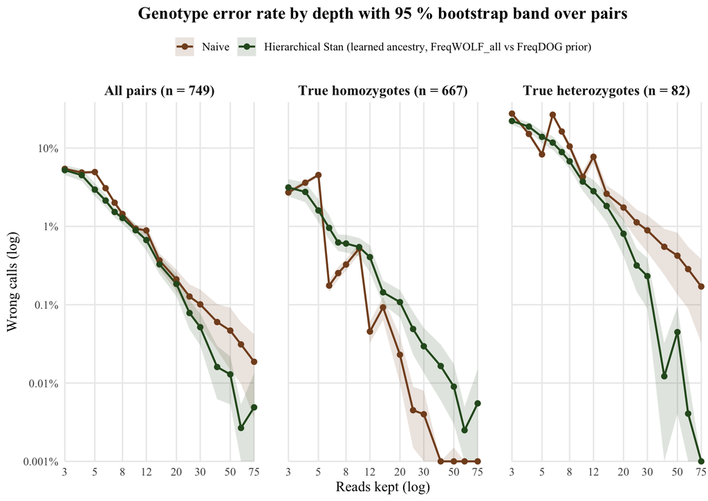

```r
### Chunk for plotting the calibration and other results from the previous data prep chunk
# Reading saves results so plotting chunks can be run without stan
if (!exists("downsampling_plot_inputs")) {
  stopifnot("no saved run with these settings, run the downsampling first" = file.exists(file.path(downsampling_output_folder, "downsampling_plot_inputs.rds")))
  downsampling_plot_inputs <- readRDS(file.path(downsampling_output_folder, "downsampling_plot_inputs.rds"))
}
invisible(list2env(downsampling_plot_inputs[names(downsampling_plot_inputs) != "downsampling_output_folder"], envir = environment()))

# Plot settings
depths_in_tradeoff_graph <- c(4, 6, 8, 10, 15, 20)
depth_colours <- setNames(colorRampPalette(c(error_colour, "#AB5D26", "#D9A877", "#E1C473", correct_colour, "#2C5724"))(length(depths_in_tradeoff_graph)),
                          paste(depths_in_tradeoff_graph, "reads"))
lowest_plotted_error <- 1e-5 # zero errors are drawn at 0.001 % on the log scales
caller_colours <- c("Naive" = "#834D24", "Hierarchical Stan" = "#2C5724")
downsampling_theme <- theme_minimal(base_family = plot_font, base_size = 12) +
  theme(plot.title = element_text(face = "bold", hjust = 0.5),
        plot.subtitle = element_text(hjust = 0.5, size = 10),
        strip.text = element_text(face = "bold", size = 12),
        legend.position = "top",
        panel.grid.minor = element_blank())

### 1. Plot, error rate against read depth
group_pair_counts <- distinct(error_by_depth_table, group, n_pairs) # one row per group, n_pairs is the same at every depth
group_panel_labels <- setNames(sprintf("%s (n = %d)", group_pair_counts$group, group_pair_counts$n_pairs), group_pair_counts$group)

error_plot_data <- bind_rows(
  error_by_depth_table %>% transmute(group, depth, caller = "Naive", error_rate = Naive, band_low = naive_low, band_high = naive_high),
  error_by_depth_table %>% transmute(group, depth, caller = "Hierarchical Stan", error_rate = `Hierarchical Stan`, band_low = stan_low, band_high = stan_high)
) %>%
  mutate(caller = factor(caller, levels = names(caller_colours)),
         across(c(error_rate, band_low, band_high), ~ pmax(.x, lowest_plotted_error))) # log scale cannot show 0

error_by_depth_plot <- ggplot(error_plot_data, aes(x = depth, y = error_rate, colour = caller, fill = caller)) +
  geom_ribbon(aes(ymin = band_low, ymax = band_high), alpha = 0.15, colour = NA) +
  geom_line(linewidth = 0.8) +
  geom_point(size = 1.8) +
  facet_wrap(~ group, labeller = as_labeller(group_panel_labels)) +
  scale_x_log10(breaks = c(3, 5, 8, 12, 20, 30, 50, 75), expand = c(0, 0)) +
  coord_cartesian(clip = "off") +
  scale_y_log10(labels = label_percent(accuracy = 0.001, drop0trailing = TRUE), breaks = c(1e-5, 1e-4, 1e-3, 1e-2, 1e-1),
                expand = expansion(mult = c(0, 0.03))) +
  scale_colour_manual(values = caller_colours, labels = c("Naive" = "Naive", "Hierarchical Stan" = sprintf("Hierarchical Stan (%s prior)", prior_description))) +
  scale_fill_manual(values = caller_colours, labels = c("Naive" = "Naive", "Hierarchical Stan" = sprintf("Hierarchical Stan (%s prior)", prior_description))) +
  labs(title = "Genotype error rate by depth with 95 % bootstrap band over pairs",
       x = "Reads kept (log)", y = "Wrong calls (log)", colour = NULL, fill = NULL) +
  downsampling_theme +
  theme(panel.spacing.x = unit(2, "lines"))
print(error_by_depth_plot)
```

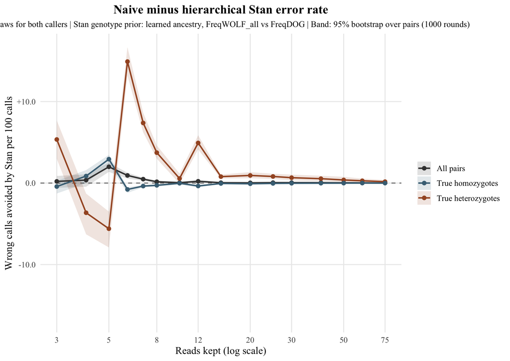

```r
### 2. Plot, paired difference naive - Stan
# Paired difference between naive and stan caller on the same draws (if its above zero Stan makes fewer errors)
caller_difference_plot <- ggplot(error_by_depth_table, aes(x = depth, y = difference, colour = group, fill = group)) +
  geom_hline(yintercept = 0, linetype = "dashed", colour = "grey50") +
  geom_blank(aes(y = -difference_low)) + # invisible mirrored band, so the y axis is symmetric around 0
  geom_blank(aes(y = -difference_high)) +
  geom_ribbon(aes(ymin = difference_low, ymax = difference_high), alpha = 0.15, colour = NA) +
  geom_line(linewidth = 0.8) +
  geom_point(size = 1.8) +
  scale_x_log10(breaks = c(3, 5, 8, 12, 20, 30, 50, 75)) +
  scale_y_continuous(labels = label_number(scale = 100, accuracy = 0.1, style_positive = "plus")) +
  scale_colour_manual(values = group_colours) +
  scale_fill_manual(values = group_colours) +
  labs(title = "Naive minus hierarchical Stan error rate",
       subtitle = sprintf("Same draws for both callers | Stan genotype prior: %s | Band: 95%% bootstrap over pairs (%d rounds)",
                          prior_description, bootstrap_rounds),
       x = "Reads kept (log scale)", y = "Wrong calls avoided by Stan per 100 calls", colour = NULL, fill = NULL) +
  downsampling_theme +
  theme(legend.position = "right")
print(caller_difference_plot)
```

```r
### 3. Plot, GQ cut-off trade-off
# GQ as a filter: per depth, share of all calls removed (cost) against share of wrong calls removed (gain), one point per threshold
gq_tradeoff_plot_data <- gq_tradeoff_table %>%
  filter(depth %in% depths_in_tradeoff_graph, !is.na(share_errors_removed)) %>%
  mutate(share_removed = 1 - share_kept,
         overall_error = error_among_kept[gq_threshold == min(gq_threshold)],
         share_correct_removed = (share_removed - overall_error * share_errors_removed) / (1 - overall_error),
         youden_index = share_errors_removed - share_correct_removed,
         depth_label = factor(paste(depth, "reads"), levels = names(depth_colours)), .by = depth) %>%
  arrange(depth, gq_threshold)

# Best threshold per depth
best_threshold_points <- gq_tradeoff_plot_data %>% slice_max(youden_index, n = 1, with_ties = FALSE, by = depth)
kable(best_threshold_points %>%
        transmute(depth, gq_threshold, 100 * share_kept, 100 * share_errors_removed, 100 * share_correct_removed, 100 * error_among_kept),
      digits = c(0, 0, 1, 1, 1, 3),
      col.names = c("Reads", "Best GQ threshold", "Calls kept (%)", "Wrong calls removed (%)", "Correct calls removed (%)", "Error among kept (%)"),
      caption = "Best GQ threshold per depth (largest Youden index)")
```

Best GQ threshold per depth (largest Youden index)

| Reads | Best GQ threshold | Calls kept (%) | Wrong calls removed (%) | Correct calls removed (%) | Error among kept (%) |
| --- | --- | --- | --- | --- | --- |
| 4 | 11 | 90.4 | 81.3 | 6.3 | 0.933 |
| 6 | 16 | 88.6 | 86.6 | 9.8 | 0.324 |
| 8 | 19 | 88.8 | 92.5 | 10.1 | 0.108 |
| 10 | 19 | 90.6 | 93.0 | 8.6 | 0.069 |
| 15 | 22 | 95.7 | 92.5 | 4.0 | 0.026 |
| 20 | 25 | 97.4 | 96.1 | 2.4 | 0.007 |

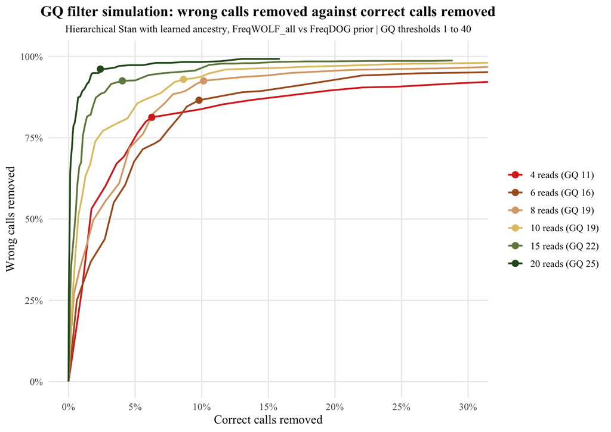

```r
# Legend entries with each depth's best threshold
depth_legend_labels <- setNames(sprintf("%s (GQ %d)", best_threshold_points$depth_label, best_threshold_points$gq_threshold),
                                best_threshold_points$depth_label)

gq_tradeoff_plot <- ggplot(gq_tradeoff_plot_data, aes(x = share_correct_removed, y = share_errors_removed, colour = depth_label)) +
  geom_path(linewidth = 0.8) +
  geom_point(data = best_threshold_points, size = 2.6) + # best threshold per depth
  scale_x_continuous(labels = percent, breaks = seq(0, 0.3, 0.05)) +
  scale_y_continuous(labels = percent, breaks = seq(0, 1, 0.25)) +
  scale_colour_manual(values = depth_colours, labels = depth_legend_labels) +
  coord_cartesian(xlim = c(0, 0.3), ylim = c(0, 1)) +
  labs(title = "GQ filter simulation: wrong calls removed against correct calls removed",
       subtitle = sprintf("Hierarchical Stan with %s prior | GQ thresholds %s to %s",
                          prior_description, min(gq_tradeoff_plot_data$gq_threshold), max(gq_tradeoff_plot_data$gq_threshold)),
       x = "Correct calls removed", y = "Wrong calls removed", colour = NULL) +
  downsampling_theme +
  theme(legend.position = "right")
print(gq_tradeoff_plot)
```

```r
### Saving plots
ggsave(file.path(downsampling_output_folder, "error_vs_depth.png"), error_by_depth_plot, width = 8.27, height = 5.85, dpi = 300, bg = "white")
ggsave(file.path(downsampling_output_folder, "error_vs_depth.pdf"), error_by_depth_plot, width = 8.27, height = 5.85, device = cairo_pdf)
ggsave(file.path(downsampling_output_folder, "caller_difference.png"), caller_difference_plot, width = 8.27, height = 5.85, dpi = 300, bg = "white")
ggsave(file.path(downsampling_output_folder, "caller_difference.pdf"), caller_difference_plot, width = 8.27, height = 5.85, device = cairo_pdf)
ggsave(file.path(downsampling_output_folder, "gq_cutoff_tradeoff.png"), gq_tradeoff_plot, width = 8.27, height = 5.85, dpi = 300, bg = "white")
ggsave(file.path(downsampling_output_folder, "gq_cutoff_tradeoff.pdf"), gq_tradeoff_plot, width = 8.27, height = 5.85, device = cairo_pdf)
```

## 4 Genotype Calibration Plot

This chunk contains data prep and genotype calibration plot.

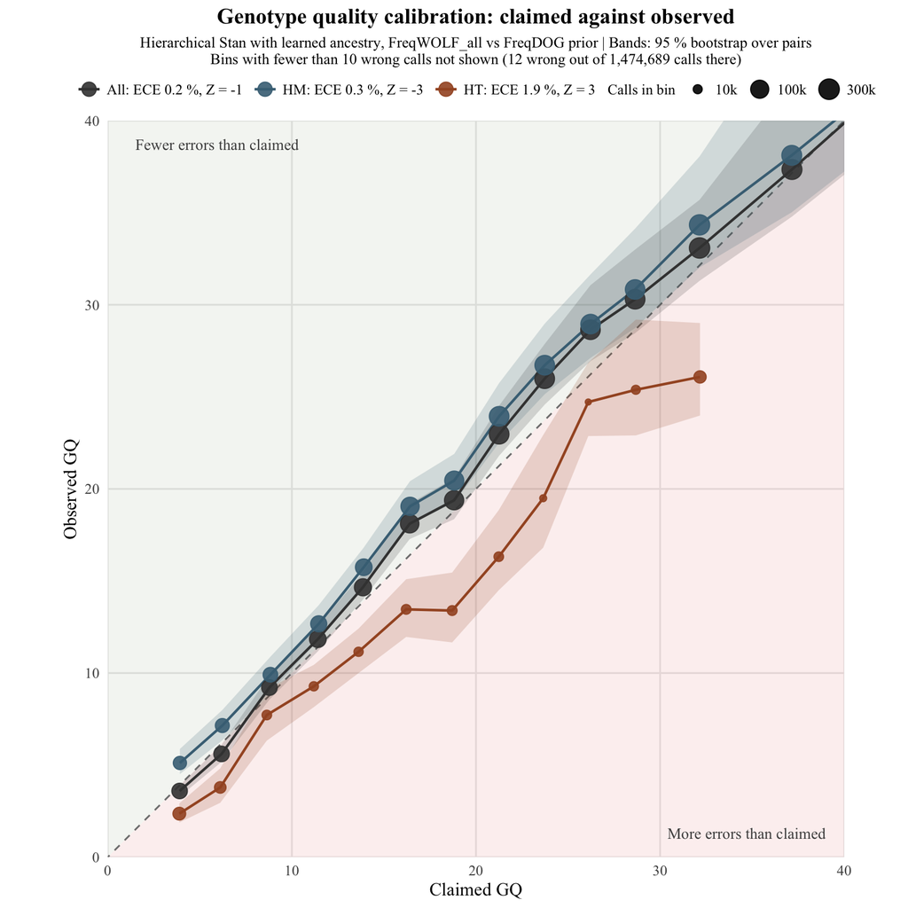

```r
### Calibration plot: HM and HT with bands
calibration_colours <- c("All calls" = "grey25", "Homozygous calls" = hm_dark, "Heterozygous calls" = ht_dark)

calibration_verdicts <- calibration_statistics_table %>%
  mutate(legend_label = sprintf("%s: ECE %.1f %%, Z = %.0f",
                                c("All calls" = "All", "Homozygous calls" = "HM", "Heterozygous calls" = "HT")[as.character(group)],
                                100 * ece, spiegelhalter_z_cluster))
calibration_legend_labels <- setNames(calibration_verdicts$legend_label, as.character(calibration_verdicts$group))

minimum_wrong_calls_per_bin <- 10 # an error rate needs enough wrong calls to be measured, bins with fewer are left out
calibration_bins <- calibration_table %>% filter(group != "All calls") %>% mutate(group = droplevels(group))
calibration_plot_data <- calibration_table %>%
  filter(n_wrong >= minimum_wrong_calls_per_bin) %>%
  mutate(group = factor(group, levels = calibration_groups)) # All calls, HM, HT in this order

hidden_bins <- calibration_bins %>% filter(n_wrong < minimum_wrong_calls_per_bin)
hidden_note <- sprintf("Bins with fewer than %d wrong calls not shown (%d wrong out of %s calls there)",
                       minimum_wrong_calls_per_bin, sum(hidden_bins$n_wrong), comma(sum(hidden_bins$n)))
phred_breaks <- seq(0, 40, 10)

calibration_plot <- ggplot(calibration_plot_data, aes(x = claimed_Q, y = empirical_Q, colour = group)) +
  annotate("polygon", x = c(0, 40, 0), y = c(0, 40, 40), fill = correct_colour, alpha = 0.08) + # background colour
  annotate("polygon", x = c(0, 40, 40), y = c(0, 0, 40), fill = error_colour, alpha = 0.08) +
  annotate("text", x = 1.5, y = 39, label = "Fewer errors than claimed", hjust = 0, vjust = 1, size = 3.6, colour = "grey30", family = plot_font) +
  annotate("text", x = 39, y = 1, label = "More errors than claimed", hjust = 1, vjust = 0, size = 3.6, colour = "grey30", family = plot_font) +
  geom_abline(slope = 1, intercept = 0, linetype = "dashed", colour = "grey50") +
  geom_ribbon(aes(ymin = bar_Q_low, ymax = bar_Q_high, fill = group), alpha = 0.18, colour = NA) +
  geom_path(linewidth = 0.8) +
  geom_point(aes(size = n), alpha = 0.9) +
  scale_colour_manual(values = calibration_colours, labels = calibration_legend_labels, name = NULL) +
  scale_fill_manual(values = calibration_colours, guide = "none") +
  scale_size_continuous(transform = "log10", range = c(1.5, 6), breaks = c(10000, 100000, 300000),
                        labels = label_number(scale = 1e-3, suffix = "k"), name = "Calls in bin") +
  scale_x_continuous(breaks = phred_breaks) +
  scale_y_continuous(breaks = phred_breaks) +
  coord_equal(xlim = c(0, 40), ylim = c(0, 40), expand = FALSE) +
  guides(colour = guide_legend(order = 1, nrow = 1, override.aes = list(size = 4)), size = guide_legend(order = 2, nrow = 1)) +
  labs(title = "Genotype quality calibration: claimed against observed",
       subtitle = sprintf("Hierarchical Stan with %s prior | Bands: 95 %% bootstrap over pairs\n%s",
                          prior_description, hidden_note),
       x = "Claimed GQ", y = "Observed GQ") +
  downsampling_theme +
  theme(legend.box = "horizontal",
        legend.title = element_text(size = rel(0.8)),
        legend.text = element_text(margin = margin(l = 3)),
        legend.key.spacing.x = unit(6, "pt"),
        legend.spacing.x = unit(8, "pt"),
        legend.margin = margin(0, 0, 0, 0))
print(calibration_plot)
```

```r
ggsave(file.path(downsampling_output_folder, "genotype_calibration.png"), calibration_plot, width = 8.27, height = 8.27, dpi = 300, bg = "white")
ggsave(file.path(downsampling_output_folder, "genotype_calibration.pdf"), calibration_plot, width = 8.27, height = 8.27, device = cairo_pdf)
```

## 5 Genotype Prior Comparison Plots

This chunk contains comparison plots between different priors used on the same settings, it contains data prep and plot for error rate and genotype calibration comparison.

```r
### Prior comparison plot with same settings but three different priors
# Importing the files
comparison_parent_folder <- file.path("Results", dataset_name, "Graphics", "STAN_Hierarchical")
comparison_folders <- file.path(comparison_parent_folder, c(
  "unpad_a3_e0.08_flat",
  "unpad_a3_e0.08_het0.15",
  "unpad_a3_e0.08_hwe_Wall_fl0.001",
  "unpad_a3_e0.08_anc_Wall_fl0.001_b1",
  "unpad_a3_e0.08_anc_WEastEurope_fl0.001_b1"), "Downsampling_calibration_sflag_r75_d75_n300") # run folders, then the downsampling folder inside each
prior_palette <- c("#E0A526", "#2F6690", "#8E5C8E", "#C2502E", "#5E8C3A")

# Saved results of each run, all runs must share the same truth set
comparison_runs <- lapply(comparison_folders, function(folder) readRDS(file.path(folder, "downsampling_plot_inputs.rds")))
stopifnot("the runs have different truth sets" = length(unique(sapply(comparison_runs, `[[`, "n_truth_pairs"))) == 1)
comparison_prior_names <- sapply(comparison_runs, `[[`, "prior_description")
prior_colours <- setNames(prior_palette, comparison_prior_names)

# Summary table: one row per prior and call type
kable(bind_rows(lapply(comparison_runs, function(run) mutate(run$calibration_statistics_table, prior = run$prior_description))) %>%
        transmute(prior, group, n_calls,
                  claimed_error_pct = round(100 * mean_claimed_error, 2), observed_error_pct = round(100 * observed_error, 2),
                  ece_pct = round(100 * ece, 2), spiegelhalter_z_cluster = round(spiegelhalter_z_cluster, 1),
                  brier = signif(brier, 3), brier_skill_score = round(brier_skill_score, 3)),
      col.names = c("Prior", "Calls", "n", "Claimed error (%)", "Observed error (%)", "ECE (%)", "Spiegelhalter Z", "Brier", "Brier skill"),
      format.args = list(big.mark = ","))
```

| Prior | Calls | n | Claimed error (%) | Observed error (%) | ECE (%) | Spiegelhalter Z | Brier | Brier skill |
| --- | --- | --- | --- | --- | --- | --- | --- | --- |
| flat | All calls | 3,595,200 | 2.55 | 1.79 | 1.11 | -14.6 | 0.01420 | 0.194 |
| flat | Homozygous calls | 3,180,527 | 2.25 | 0.68 | 1.57 | -14.9 | 0.00754 | -0.114 |
| flat | Heterozygous calls | 414,673 | 4.86 | 10.31 | 5.45 | 12.2 | 0.06510 | 0.295 |
| het share 0.15 | All calls | 3,370,500 | 1.74 | 1.62 | 0.25 | -2.3 | 0.01260 | 0.214 |
| het share 0.15 | Homozygous calls | 3,011,560 | 1.31 | 1.08 | 0.26 | -2.4 | 0.00904 | 0.151 |
| het share 0.15 | Heterozygous calls | 358,940 | 5.31 | 6.23 | 0.92 | 2.5 | 0.04200 | 0.280 |
| FreqWOLF_all | All calls | 3,370,500 | 1.35 | 3.16 | 1.81 | 5.7 | 0.02470 | 0.195 |
| FreqWOLF_all | Homozygous calls | 2,966,041 | 0.87 | 1.20 | 0.46 | 3.2 | 0.01030 | 0.129 |
| FreqWOLF_all | Heterozygous calls | 404,459 | 4.86 | 17.55 | 12.69 | 4.5 | 0.13000 | 0.103 |
| learned ancestry, FreqWOLF_all vs FreqDOG | All calls | 3,595,200 | 1.27 | 1.24 | 0.17 | -1.4 | 0.00925 | 0.245 |
| learned ancestry, FreqWOLF_all vs FreqDOG | Homozygous calls | 3,202,250 | 0.98 | 0.71 | 0.28 | -3.0 | 0.00610 | 0.131 |
| learned ancestry, FreqWOLF_all vs FreqDOG | Heterozygous calls | 392,950 | 3.65 | 5.60 | 1.95 | 3.0 | 0.03490 | 0.339 |
| learned ancestry, FreqWOLF_EastEurope vs FreqDOG | All calls | 3,595,200 | 1.21 | 1.18 | 0.08 | -0.9 | 0.00889 | 0.238 |
| learned ancestry, FreqWOLF_EastEurope vs FreqDOG | Homozygous calls | 3,203,887 | 0.91 | 0.70 | 0.21 | -2.1 | 0.00602 | 0.132 |
| learned ancestry, FreqWOLF_EastEurope vs FreqDOG | Heterozygous calls | 391,313 | 3.68 | 5.13 | 1.45 | 2.4 | 0.03240 | 0.334 |

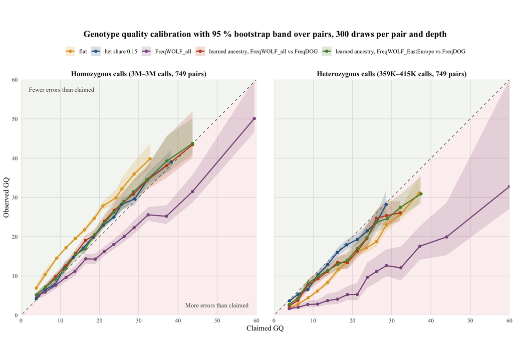

```r
# Calibration: bins with enough wrong calls, one line per prior, homozygous and heterozygous calls in separate panels
calibration_comparison_data <- bind_rows(lapply(comparison_runs, function(run) mutate(run$calibration_table, prior = run$prior_description))) %>%
  filter(group != "All calls", n_wrong >= minimum_wrong_calls_per_bin) %>%
  mutate(group = factor(group, levels = c("Homozygous calls", "Heterozygous calls")),
         prior = factor(prior, levels= comparison_prior_names))

# Panel titles with the number of calls in each group, as a range over the priors (each prior calls a few more or fewer homozygotes)
calls_per_group <- bind_rows(lapply(comparison_runs, function(run) run$calibration_statistics_table)) %>%
  filter(group != "All calls") %>%
  summarise(fewest = min(n_calls), most = max(n_calls), .by = group)
calibration_panel_labels <- setNames(sprintf("%s (%s\u2013%s calls, %d pairs)", calls_per_group$group,
                                             label_number(scale_cut = cut_short_scale())(signif(calls_per_group$fewest, 3)),
                                             label_number(scale_cut = cut_short_scale())(signif(calls_per_group$most, 3)),
                                             comparison_runs[[1]]$n_truth_pairs), # calls of both panels come from the whole truth set
                                     calls_per_group$group)

calibration_comparison_plot <- ggplot(calibration_comparison_data, aes(x = claimed_Q, y = empirical_Q, colour = prior, fill = prior)) +
  annotate("polygon", x = c(0, 60, 0), y = c(0, 60, 60), fill = correct_colour, alpha = 0.08) +
  annotate("polygon", x = c(0, 60, 60), y = c(0, 0, 60), fill = error_colour, alpha = 0.08) +
  geom_text(data = data.frame(group = factor("Homozygous calls", levels = c("Homozygous calls", "Heterozygous calls")),
                              x = c(2, 58), y = c(58, 2), label = c("Fewer errors than claimed", "More errors than claimed"),
                              hjust = c(0, 1), vjust = c(1, 0)),
            aes(x = x, y = y, label = label, hjust = hjust, vjust = vjust),
            size = 3.6, colour = "grey30", family = plot_font, inherit.aes = FALSE) +
  geom_abline(slope = 1, intercept = 0, linetype = "dashed", colour = "grey50") +
  geom_ribbon(aes(ymin = bar_Q_low, ymax = bar_Q_high), alpha = 0.18, colour = NA) +
  geom_path(linewidth = 0.9) +
  geom_point(size = 1.8) +
  facet_wrap(~ group, labeller = as_labeller(calibration_panel_labels)) +
  scale_colour_manual(values = prior_colours) +
  scale_fill_manual(values = prior_colours) +
  scale_x_continuous(breaks = seq(0, 60, 10)) +
  scale_y_continuous(breaks = seq(0, 60, 10)) +
  coord_equal(xlim = c(0, 60), ylim = c(0, 60), expand = FALSE) +
  guides(colour = guide_legend(nrow = 1), fill = guide_legend(nrow = 1)) +
  labs(title = sprintf("Genotype quality calibration with 95 %% bootstrap band over pairs, %d draws per pair and depth",
                       comparison_runs[[1]]$draws_per_depth),
       x = "Claimed GQ", y = "Observed GQ", colour = NULL, fill = NULL) +
    downsampling_theme +
  theme(panel.spacing.x = unit(2, "lines")) # space between the two panels
print(calibration_comparison_plot)
```

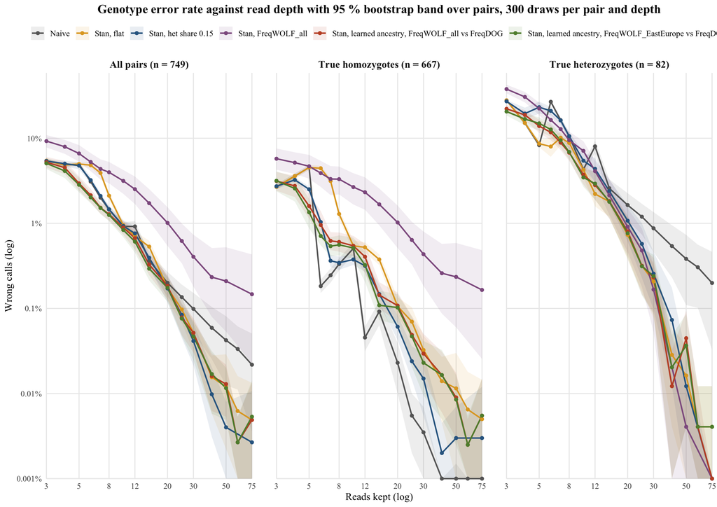

```r
# Error rate against depth: the naive caller once (same draws in every run) and Stan once per prior
error_comparison_data <- bind_rows(
  comparison_runs[[1]]$error_by_depth_table %>%
    transmute(group, depth, line = "Naive", error_rate = Naive, band_low = naive_low, band_high = naive_high),
  bind_rows(lapply(comparison_runs, function(run) mutate(run$error_by_depth_table, prior = run$prior_description))) %>%
    transmute(group, depth, line = paste("Stan,", prior), error_rate = `Hierarchical Stan`, band_low = stan_low, band_high = stan_high)) %>%
  mutate(line = factor(line, levels = c("Naive", paste("Stan,", comparison_prior_names))),
         across(c(error_rate, band_low, band_high), ~ pmax(.x, lowest_plotted_error))) # log scale cannot show 0
error_line_colours <- setNames(c("grey40", prior_colours), c("Naive", paste("Stan,", comparison_prior_names)))


group_pair_counts <- distinct(comparison_runs[[1]]$error_by_depth_table, group, n_pairs)
group_panel_labels <- setNames(sprintf("%s (n = %d)", group_pair_counts$group, group_pair_counts$n_pairs), group_pair_counts$group)

error_comparison_plot <- ggplot(error_comparison_data, aes(x = depth, y = error_rate, colour = line, fill = line)) +
  geom_ribbon(aes(ymin = band_low, ymax = band_high), alpha = 0.1, colour = NA) +
  geom_line(linewidth = 0.8) +
  geom_point(size = 1.5) +
  facet_wrap(~ group, labeller = as_labeller(group_panel_labels)) +
  scale_x_log10(breaks = c(3, 5, 8, 12, 20, 30, 50, 75), expand = c(0, 0)) +
  coord_cartesian(clip = "off") +
  scale_y_log10(labels = label_percent(accuracy = 0.001, drop0trailing = TRUE), breaks = c(1e-5, 1e-4, 1e-3, 1e-2, 1e-1),
                expand = expansion(mult = c(0, 0.03))) +
  scale_colour_manual(values = error_line_colours) +
  scale_fill_manual(values = error_line_colours) +
  guides(colour = guide_legend(nrow = 1), fill = guide_legend(nrow = 1)) +
  labs(title = sprintf("Genotype error rate against read depth with 95 %% bootstrap band over pairs, %d draws per pair and depth",
                       comparison_runs[[1]]$draws_per_depth),
       x = "Reads kept (log)", y = "Wrong calls (log)", colour = NULL, fill = NULL) +
  downsampling_theme +
  theme(panel.spacing.x = unit(2, "lines"))

print(error_comparison_plot)
```

```r
ggsave(file.path(comparison_parent_folder, "prior_comparison_calibration.png"), calibration_comparison_plot, width = 11.69, height = 8.27, dpi = 300, bg = "white")
ggsave(file.path(comparison_parent_folder, "prior_comparison_calibration.pdf"), calibration_comparison_plot, width = 11.69, height = 8.27, device = cairo_pdf)
ggsave(file.path(comparison_parent_folder, "prior_comparison_error_vs_depth.png"), error_comparison_plot, width = 11.69, height = 8.27, dpi = 300, bg = "white")
ggsave(file.path(comparison_parent_folder, "prior_comparison_error_vs_depth.pdf"), error_comparison_plot, width = 11.69, height = 8.27, device = cairo_pdf)
```

## 6 Stan Diagnostic Plots

This chunk contains MCMC diagnostic plots made with bayesplot package. it contains rank histograms, trace plots, Rhat, effective sample size, and so on.

```r
### MCMC diagnostics plots saved to hierarchical bayes folder from the second chunk
# Ulpoading saved .rds results
if (!exists("fit_hier")) {
  stan_plot_inputs_file <- file.path("Results", dataset_name, "Genotypes_results", run_names$bayes_run_name, "stan_plot_inputs.rds")
  stopifnot("no saved Stan run with these settings, run the Stan model first" = file.exists(stan_plot_inputs_file))
  list2env(readRDS(stan_plot_inputs_file), envir = environment())
}
```

```
<environment: 0x104122bf0>
```

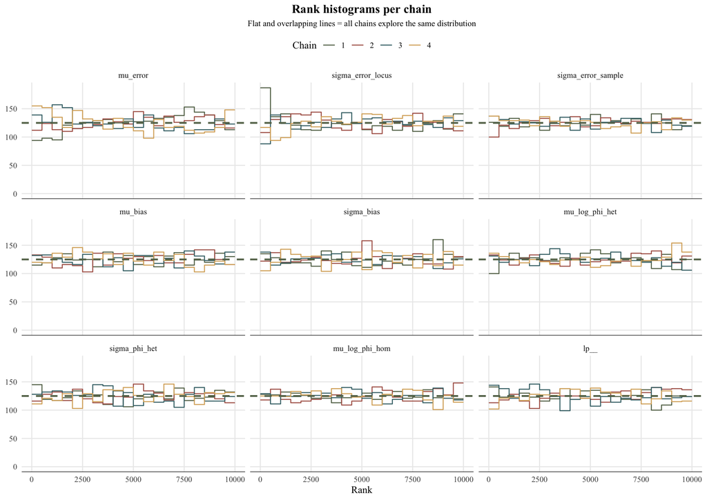

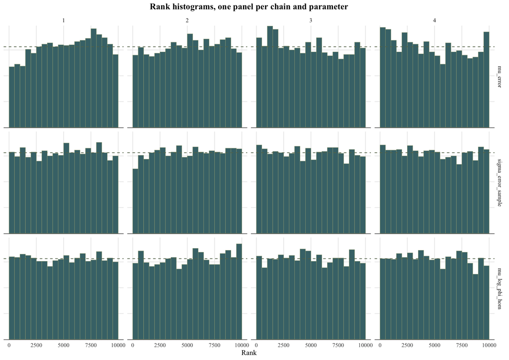

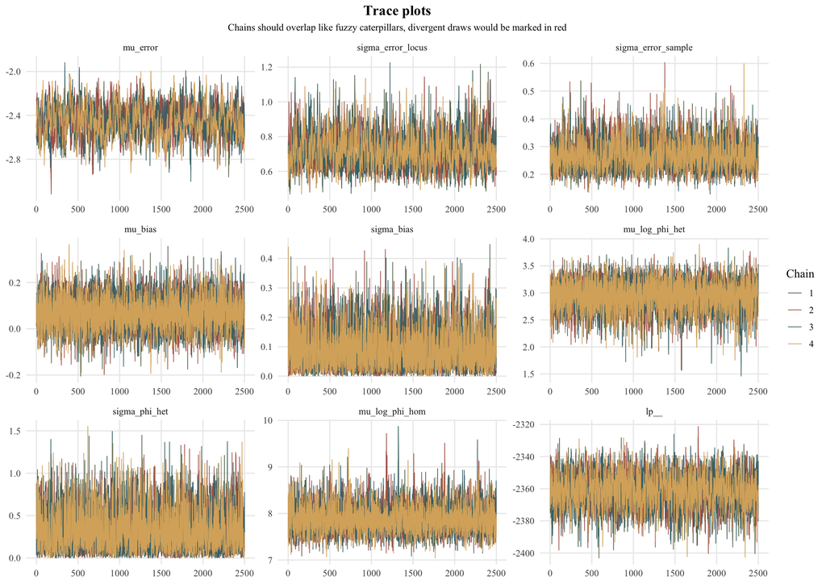

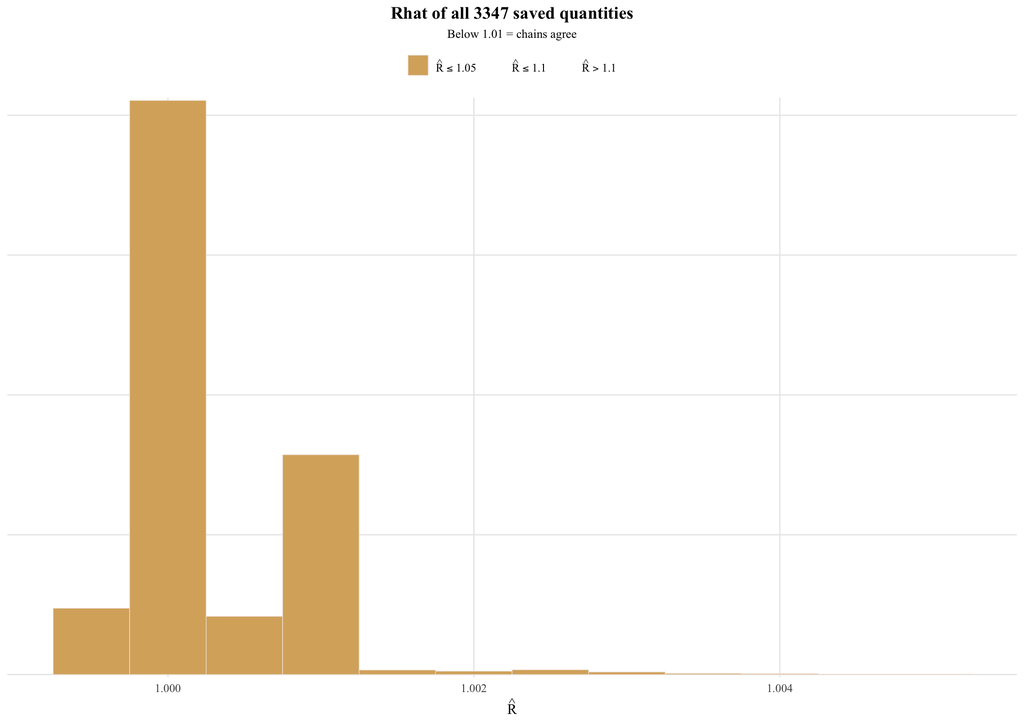

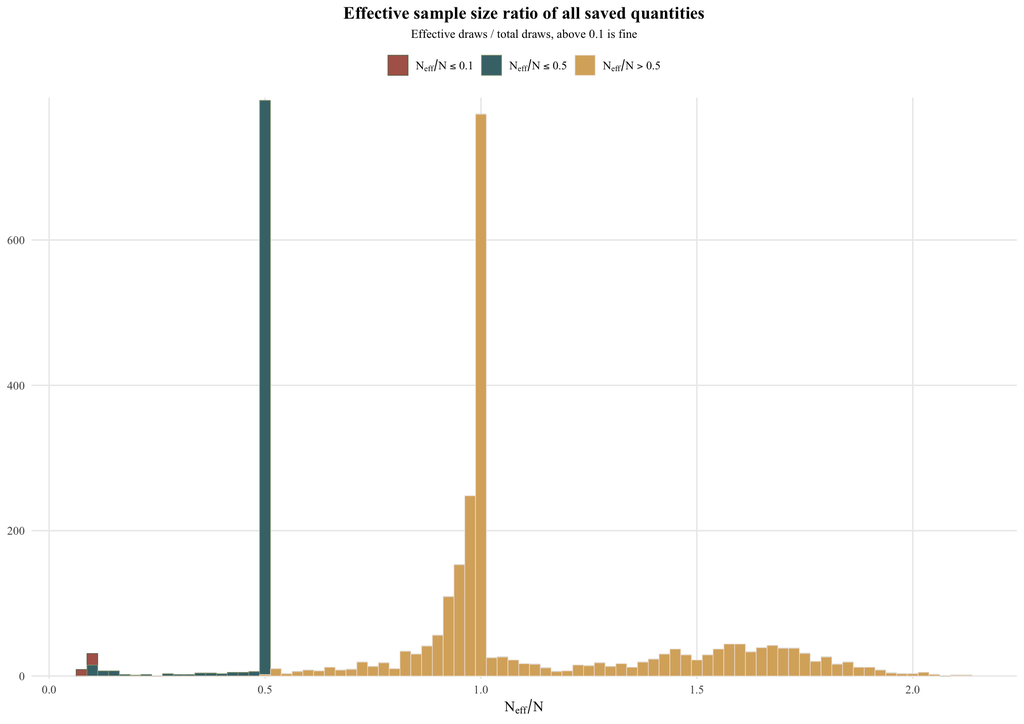

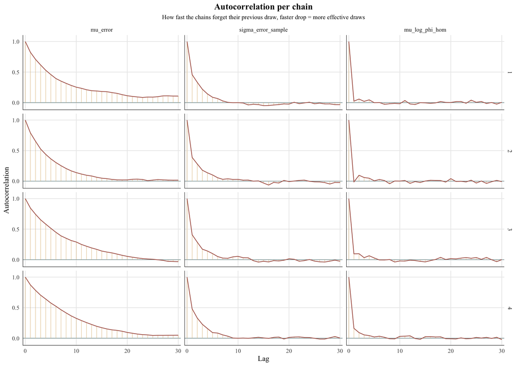

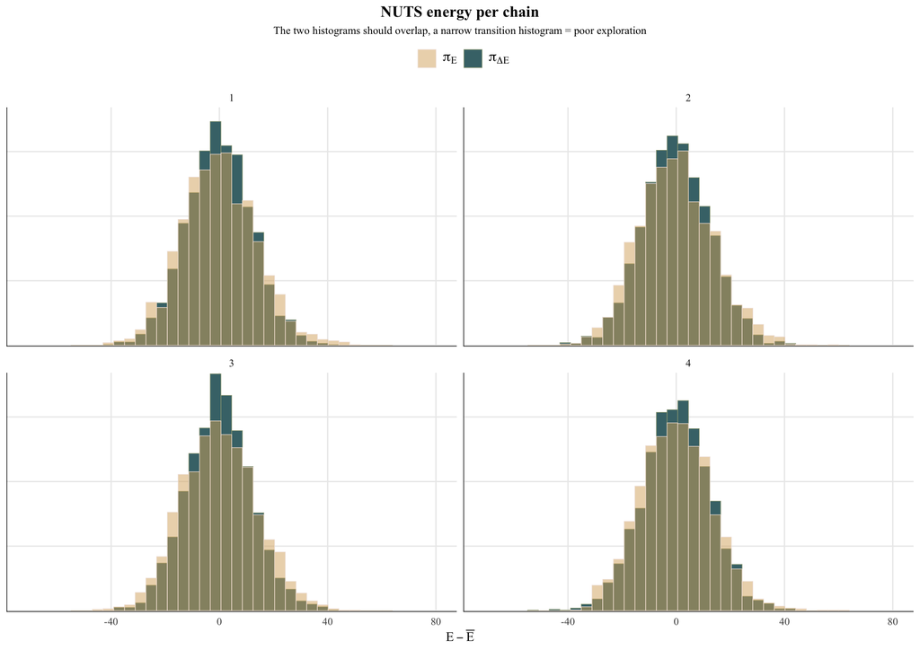

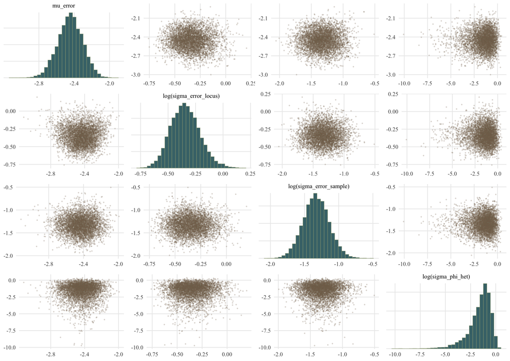

```r
stan_diagnostics_folder <- file.path(stan_graphics_folder, "Stan_Diagnostics_Plots")
dir.create(stan_diagnostics_folder, showWarnings = FALSE, recursive = TRUE)

color_scheme_set(c("#D9AF6B", "#F1E4DB", "#467378", "#9AA582", "#AF6458", "#657359"))
bayesplot_theme_set(theme_minimal(base_family = plot_font, base_size = 12) +
                      theme(plot.title = element_text(face = "bold", hjust = 0.5),
                            plot.subtitle = element_text(hjust = 0.5, size = 10),
                            legend.position = "top",
                            panel.grid.minor = element_blank()))

# Which mdoel parameters to plot
phi_hom_parameter <- intersect(c("phi_hom", "mu_log_phi_hom"), fit_hier@model_pars)[1] # list of the parameters
diagnostic_pars <- c("mu_error", # typical sequencing error rate (logit scale)
                     "sigma_error_locus", # how much error rate differs between loci
                     "sigma_error_sample", # between samples
                     "mu_bias", # typical allele balance in HT (logit scale, 0 = 50/50)
                     "sigma_bias", # how much allele balance differs between loci
                     "mu_log_phi_het", # typical overdispersion in HT (log scale)
                     "sigma_phi_het", # how much it differs between samples
                     phi_hom_parameter, # overdispersion in HM  (either shared, locus, sample or locussample)
                     "lp__") # log posterior, how well the parameters fit the data and priors
slow_mixing_pars <- c("mu_error", "sigma_error_sample", phi_hom_parameter) # the three shown in the rank histogram and autocorrelation plots
posterior_array_hier <- as.array(fit_hier, pars = diagnostic_pars) # draws*chains*parameters
nuts_hier <- nuts_params(fit_hier) # divergences, tree depth and energy of every draw

# Rhat of every parameter and effective sample size ratio of every parameter (how many independent draws are my draws worth)
rhat_hier <- rhat(fit_hier) # measures if the chains agree with each other
neff_ratio_hier <- neff_ratio(fit_hier) # shouldnt be belowe 0.1

# Plots made inside a list so it can later be used inside for loop, i can get rid of a lot of unnecessary ggsave lines for all the plots
stan_diagnostic_plots <- list(
  rank_overlay = mcmc_rank_overlay(posterior_array_hier, ref_line = TRUE, facet_args = list(ncol = 3)) +
    labs(title = "Rank histograms per chain",
         subtitle = "Flat and overlapping lines = all chains explore the same distribution"),
  rank_hist = mcmc_rank_hist(posterior_array_hier, pars = slow_mixing_pars, ref_line = TRUE) +
    labs(title = "Rank histograms, one panel per chain and parameter"),
  trace = mcmc_trace(posterior_array_hier, np = nuts_hier, facet_args = list(ncol = 3)) +
    labs(title = "Trace plots", subtitle = "Chains should overlap like fuzzy caterpillars, divergent draws would be marked in red"),
  rhat = mcmc_rhat_hist(rhat_hier[is.finite(rhat_hier)], binwidth = 0.0005) +
    labs(title = sprintf("Rhat of all %d saved quantities", sum(is.finite(rhat_hier))), subtitle = "Below 1.01 = chains agree"),
  neff = mcmc_neff_hist(neff_ratio_hier[is.finite(neff_ratio_hier)], binwidth = 0.025) +
    labs(title = "Effective sample size ratio of all saved quantities", subtitle = "Effective draws / total draws, above 0.1 is fine"),
  autocorrelation = mcmc_acf(posterior_array_hier, pars = slow_mixing_pars, lags = 30) +
    labs(title = "Autocorrelation per chain", subtitle = "How fast the chains forget their previous draw, faster drop = more effective draws"),
  energy = mcmc_nuts_energy(nuts_hier) +
    labs(title = "NUTS energy per chain", subtitle = "The two histograms should overlap, a narrow transition histogram = poor exploration"),
  pairs = mcmc_pairs(posterior_array_hier, pars = c("mu_error", "sigma_error_locus", "sigma_error_sample", "sigma_phi_het"),
                     transformations = list(sigma_error_locus = "log", sigma_error_sample = "log", sigma_phi_het = "log"),
                     np = nuts_hier, off_diag_args = list(size = 0.4, alpha = 0.2),
                     diag_args = list(bins = 40)))
suppressMessages(for (plot_name in names(stan_diagnostic_plots)) {
  print(stan_diagnostic_plots[[plot_name]])
  ggsave(file.path(stan_diagnostics_folder, paste0("diagnostics_", plot_name, ".png")), stan_diagnostic_plots[[plot_name]],
         width = 11.69, height = 8.27, dpi = 300, bg = "white")
  ggsave(file.path(stan_diagnostics_folder, paste0("diagnostics_", plot_name, ".pdf")), stan_diagnostic_plots[[plot_name]],
         width = 11.69, height = 8.27, device = cairo_pdf)
})
```

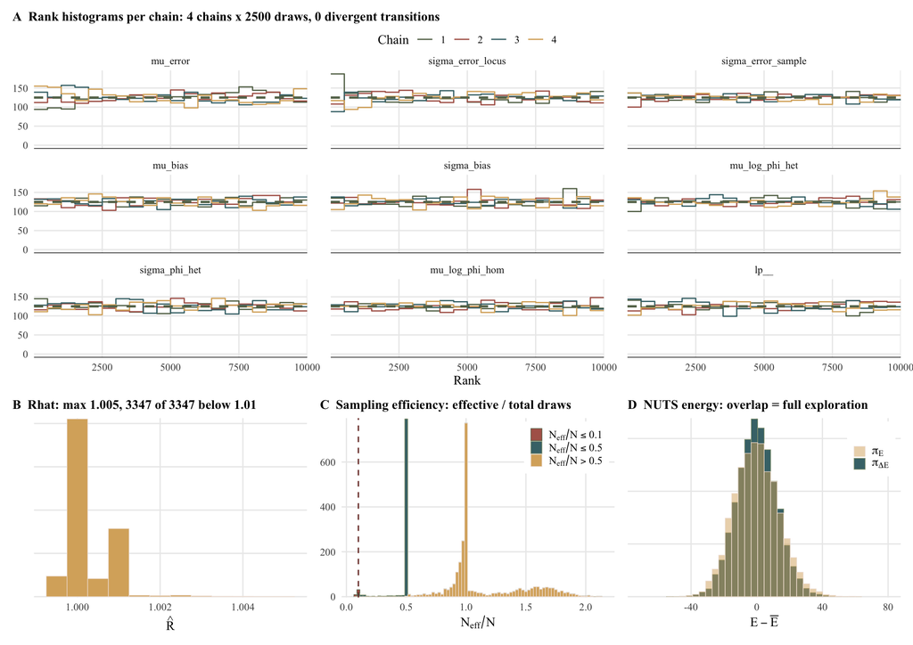

```r
### Combined diagnostics figure: chain agreement, convergence of all parameters, efficiency and exploration
diagnostics_panel_theme <- theme(plot.title = element_text(face = "bold", hjust = 0, size = 12),
                                 plot.subtitle = element_text(hjust = 0, size = 9),
                                 plot.title.position = "plot")

stan_diagnostics_panel <- wrap_plots(
  A = stan_diagnostic_plots$rank_overlay +
    scale_x_continuous(expand = c(0, 0)) +
    labs(title = sprintf("A  Rank histograms per chain: %d chains x %d draws, %d divergent transitions",
                         stan_chains, stan_iter - stan_warmup, get_num_divergent(fit_hier)),
         subtitle = NULL) +
    diagnostics_panel_theme + theme(panel.spacing.x = unit(1.5, "lines"),
                                    legend.margin = margin(0, 0, 0, 0),
                                    legend.box.spacing = unit(2, "pt")),
  B = stan_diagnostic_plots$rhat +
    labs(title = sprintf("B  Rhat: max %.3f, %d of %d below 1.01", max(rhat_hier, na.rm = TRUE),
                         sum(rhat_hier < 1.01, na.rm = TRUE), sum(is.finite(rhat_hier))),
         subtitle = NULL) +
    diagnostics_panel_theme + theme(legend.position = "none"),
  C = stan_diagnostic_plots$neff +
    geom_vline(xintercept = 0.1, linetype = "dashed", colour = "#7E4038", linewidth = 0.6) + # 0.1 = threshold
    labs(title = "C  Sampling efficiency: effective / total draws", subtitle = NULL) + diagnostics_panel_theme +
    theme(legend.text = element_text(size = 10),
          legend.key.size = unit(11, "pt"),
          legend.position = "inside",
          legend.position.inside = c(0.98, 0.98), legend.justification.inside = c(1, 1),
          legend.direction = "vertical",
          legend.background = element_rect(fill = "white", colour = NA)),
  D = mcmc_nuts_energy(nuts_hier, merge_chains = TRUE) +
    labs(title = "D  NUTS energy: overlap = full exploration", subtitle = NULL) + diagnostics_panel_theme +
    theme(legend.text = element_text(size = 11),
          legend.key.size = unit(11, "pt"),
          legend.position = "inside",
          legend.position.inside = c(0.98, 0.98), legend.justification.inside = c(1, 1),
          legend.direction = "vertical",
          legend.background = element_rect(fill = "white", colour = NA)),
  design = "AAA\nBCD", heights = c(1.6, 1))

print(stan_diagnostics_panel)
```

```r
ggsave(file.path(stan_diagnostics_folder, "diagnostics_panel.png"), stan_diagnostics_panel, width = 11.69, height = 8.27, dpi = 300, bg = "white")
ggsave(file.path(stan_diagnostics_folder, "diagnostics_panel.pdf"), stan_diagnostics_panel, width = 11.69, height = 8.27, device = cairo_pdf)
```

**Settings used for this run**

| Setting | Value |
| --- | --- |
| run_date | 2026-10-31 19:35 |
| dataset_name | big |
| primer_panel_path | Data/Supporting_data/Primer_panels/12864_2021_7761_MOESM12_ESM_filtered.xlsx |
| minimum_required_depth | 3 |
| HT_min_frequence | 0.2 |
| n_cores | 4 |
| input_type | unpadded |
| use_anchors | TRUE |
| anchor_length | 3 |
| probe_type | asp_primers |
| threshold_type | errors |
| min_score_fraction | 0.65 |
| error_rate | 0.08 |
| strand_flag_prob | 0.01 |
| expected_minor_fraction | 0.44 |
| strand_downgrade | FALSE |
| run_stan | FALSE |
| run_downsampling | FALSE |
| run_stan_plots | TRUE |
| prior_type | ancestry |
| prior_het_share | 0.15 |
| prior_population | FreqWOLF_all |
| prior_floor | 0.001 |
| ancestry_prior_shape | 1 |
| phi_hom_structure | shared |
| stan_iter | 4000 |
| stan_warmup | 1500 |
| stan_chains | 4 |
| stan_adapt_delta | 0.95 |
| max_error | 0.1 |
| read_depths_to_test | 3, 4, 5, 6, 7, 8, 10, 12, 15, 20, 25, 30, 40, 50, 60, 75 |
| draws_per_depth | 300 |
| minimum_reads_for_truth_pair | 75 |
| bootstrap_rounds | 1000 |